# Exploratory Mediation Analysis of the Example Datasets of the HIMA Library

Nandish Verma

## Introduction

This report provides an exploratory mediation analysis of the example datasets provided in the HIMA library by Hinan Zheng. The objective of this analysis is to understand the necessity in accounting for mediators in analyzing cause and effect relationships, as well as to understand how the estimation of the contributions pathway relates to other elements of the data. To obtain these estimates, we’ll use the functions provided in the HIMA library to identify the mediators, and use the alpha and beta coefficients provided in the outputs of the functions to get a numerical value for the estimates.

## Pseudocode Explanations of HIMA Functions

### classicHIMA(X, M, Y, …)

- **Set Up Analysis**
  - Identify outcome family based on `Y.type` (“gaussian” for continuous, “binomial” for binary).
  - Validate and prepare penalty type.
  - If parallel computation is requested, determine the number of cores.
- **Data Preprocessing**
  - Scale variables `X` and `M` if required.
  - Scale covariates `COV.XM` and `COV.MY` if present.
- **Determine Number of Mediators (`d`)**
  - If `topN` is not provided, calculate `d` based on data size.
  - Limit `d` to the number of available mediators.
- **Step 1: Sure Independent Screening**
  - If `Y.type` is “binary”:
    - Perform screening to evaluate the association between `X` and each mediator `M`.
  - If `Y.type` is “continuous”:
    - Perform screening to evaluate the association between each mediator `M` and `Y`.
  - Sort mediators by their p-values and select the top `d` mediators.
- **Step 2: Penalized Regression Estimation**
  - Construct the design matrix including selected mediators and `X`.
  - If `COV.MY` is provided, adjust for these covariates in the model.
  - Fit a penalized regression model using the specified penalty.
  - Select the optimal penalty parameter (`lambda`) based on BIC.
- **Identify Non-Zero Coefficients**
  - Extract mediators with non-zero estimates from the penalized regression.
  - If no mediators are significant, return `NULL`.
  - Otherwise, proceed to calculate the indirect effect.
- **Step 3: Joint Significance Test**
  - Estimate the effect of `X` on mediators (`alpha`) if `Y.type` is “continuous”.
  - Calculate the mediation (indirect) effect for each mediator.
  - Perform significance testing for the indirect effect using the maximum p-value approach.
  - Apply the Bonferroni correction to identify significant mediators.
- **Output Results**
  - Return a data frame containing:
    - Mediator indices
    - Estimates of `alpha` and `beta`
    - Indirect effect size (`IDE`)
    - Relative importance (`rimp`)
    - Adjusted p-values
- **Completion**
  - Stop parallel computation and return the results.

### dblassohima(X, M, Y, …)

- **Initialization**
  - Get the number of samples `n` and the number of mediators `p`.
  - Scale the variables `X` and `M` if needed.
  - Scale the covariates `COV` if provided.
- **Prepare Design Matrices**
  - If `COV` is not provided, create matrices `MZX` and `XZ` using `M` and `X`.
  - If `COV` is provided, include `COV` in `MZX` and `XZ`.
  - Determine the number of covariates `q`.
- **Determine Number of Mediators (`d`)**
  - Calculate `d` based on the sample size if `topN` is not specified.
  - Limit `d` to the total number of mediators `p`.
- **Step 1: Sure Independent Screening (SIS)**
  - **Goal:** Identify the top mediators associated with exposure `X`.
  - For each mediator:
    - Estimate the regression coefficient `beta` for the mediator on `Y`.
    - Estimate the regression coefficient `alpha` for `X` on the mediator.
  - Calculate the product `alpha * beta` for each mediator.
  - Select the top `d` mediators with the largest absolute `alpha * beta` values.
- **Step 2: De-biased Lasso Estimation**
  - **Goal:** Refine the estimates using de-biased lasso.
  - If `COV` is provided, adjust for covariates in the lasso model.
  - Fit a de-biased lasso model to estimate regression coefficients `beta` for the selected mediators.
  - Compute standard errors and p-values for the `beta` estimates.
- **Estimate `alpha` Coefficients**
  - For each selected mediator:
    - Estimate the regression coefficient `alpha` for `X` on the mediator.
    - Compute the standard error and p-value for the `alpha` estimate.
- **Step 3: Multiple Testing Procedure**
  - **Goal:** Control the false discovery rate (FDR).
  - Combine p-values from the `alpha` and `beta` tests.
  - Estimate the null proportions for multiple testing.
  - Compute the FDR for each mediator and identify significant mediators using the `FDRcut` threshold.
- **Extract Significant Mediators**
  - If significant mediators are found:
    - Calculate the indirect effect (`IDE`) for each mediator.
    - Compute the relative importance of each mediator.
    - Create a data frame with the results.
  - If no significant mediators are identified, return `NULL`.
- **Output Results**
  - Return a data frame with:
    - Mediator indices
    - Estimates and standard errors for `alpha` and `beta`
    - Indirect effect size (`IDE`)
    - Relative importance
    - Adjusted p-values
- **Completion**
  - Print a message if verbose output is enabled.
  - Return the final results.

### eHIMA(X, M, Y, …)

- **Initialization**
  - Get the number of samples `n` and the number of mediators `p`.
  - Scale variables `X` and `M` if necessary.
  - Scale covariates `COV` if provided.
  - Construct design matrices:
    - If `COV` is not provided, combine `M` and `X`.
    - If `COV` is provided, combine `M`, `COV`, and `X`.
- **Determine Number of Mediators (`d`)**
  - Calculate `d` based on sample size if `topN` is not specified.
  - Ensure `d` does not exceed the total number of mediators `p`.
- **Step 1: Mediator Screening Using SIS + MCP**
  - **Goal:** Identify top mediators associated with exposure `X`.
  - For each mediator:
    - Fit a regression model to estimate the effect (`beta_SIS`) of the mediator on `Y`.
    - Fit a regression model to estimate the effect (`alpha_SIS`) of `X` on the mediator.
  - Calculate `ab_SIS = alpha_SIS * beta_SIS`.
  - Select the top `d` mediators with the largest absolute `ab_SIS` values.
  - Fit a penalized regression model using MCP to refine mediator selection.
  - Identify mediators with non-zero coefficients from the MCP model.
- **Step 2: Refitted Partial Regression**
  - **Goal:** Refine estimates for the selected mediators.
  - Fit a regression model using only the selected mediators and covariates.
  - Compute estimates, standard errors, and p-values for the `beta` coefficients.
  - Compute refined `alpha` estimates for the selected mediators.
  - For mediators not initially selected, perform an additional regression to estimate their effects.
- **Step 3: Divide-Aggregate Composite-Null Test (DACT)**
  - **Goal:** Test the significance of the mediation effect.
  - Apply the DACT procedure using the p-values from `alpha` and `beta` tests.
  - Use the Benjamini-Hochberg method to control the FDR.
  - Identify significant mediators.
- **Compute Indirect Effects**
  - Calculate the indirect effect (`IDE`) for each significant mediator.
  - Compute the relative importance of each mediator.
- **Output Results**
  - If significant mediators are found, return a data frame with:
    - Mediator indices
    - Estimates and standard errors for `alpha` and `beta`
    - Indirect effect size (`IDE`)
    - Relative importance
    - Adjusted p-values
  - If no significant mediators are found, return `NULL`.
- **Completion**
  - Print messages if `verbose` is enabled.
  - Return the final results.

### microHIMA(X, M, Y, …)

- **Preprocess Input Data:**
  - Convert `X` to a matrix with one column.
  - Convert `OTU` to a matrix `M_raw` of potential mediators.
  - Extract or assign mediator names to `M_ID_name`.
  - If `COV` is provided, convert it to a matrix and combine it with `X`.
  - Scale `X` and center `Y` around its mean.
- **Initialize Variables:**
  - Set `n` as the number of samples and `d` as the number of mediators.
  - Create matrices to store `alpha` and `beta` estimates, standard errors, and p-values.
  - Save the first column of `M_raw` as `M1` for swapping later.
- **Step 1: ILR Transformation and De-Biased Lasso Estimates**
  - **Loop Over Each Mediator (`k`):**
    1. **Rearrange Mediators:**
       - Swap the `k`-th mediator with the first mediator in `M`.
    2. **Perform ILR Transformation:**
       - For each sample:
         - Compute constants `C_1` and `C_2`.
         - Apply the isometric log-ratio transformation to generate the matrix `MT`.
    3. **Standardize `MT`:**
       - Scale the transformed matrix `MT`.
    4. **Create Design Matrix:**
       - Combine `MT` and `X` to form `MX`.
    5. **De-Biased Lasso Regression:**
       - Use `DLASSO_fun` to fit a de-biased lasso model on `MX` and `Y`.
       - Extract `beta` estimate, standard error, and compute the p-value.
       - Save `beta` estimate and standard error in matrices.
    6. **Linear Regression for `alpha`:**
       - Fit a linear regression model for the association between `X` and the first mediator in `MT`.
       - Extract `alpha` estimate, standard error, and compute the p-value.
       - Save `alpha` estimate, standard error, and the maximum p-value of `P_a` and `P_b`.
- **Step 2: Closed Testing-Based Procedure:**
  - **Adjust P-Values Using FDR:**
    1. Identify mediators with adjusted p-values less than `FDRcut`.
    2. Use the `hommel` package to perform a closed testing procedure to control FDR.
    3. Calculate the number of significant mediators incrementally.
    4. Identify mediators where the closed testing method indicates significance.
- **Compute Indirect Effects:**
  - Calculate the indirect effect (`IDE`) for each significant mediator as the product of `alpha` and `beta` estimates.
- **Prepare Output:**
  - If significant mediators are identified:
    - Create a data frame with:
      - Mediator indices
      - Estimates and standard errors for `alpha` and `beta`
      - Indirect effect size (`IDE`)
      - Relative importance (`rimp`)
      - Adjusted p-values (`pmax`)
  - If no mediators are significant, set the result to `NULL`.
- **Completion:**
  - If `verbose` is `TRUE`, print messages summarizing the results.
  - Return the final output.

### qHIMA(X, M, Y, …)

- **Setup and Initialization:**
  - Set the penalty type based on user input.
  - Get the number of samples `n` and number of mediators `p`.
  - Scale `X`, `M`, and `COV` (if provided) based on the `scale` flag.
  - Combine `X` with `COV` to create `XZ`.
  - Determine the number of mediators to select (`d`), based on `topN` or calculated value.
  - Initialize an empty `out_result` to store the final results.
- **Loop Over Each Quantile Level (`tau`):**
  - Print a message indicating the start of quantile regression for the given `tau`.
- **Step 1: Mediator Screening**
  - Loop over each mediator `k`:
    - Create a design matrix `MXZ_k` by combining the `k`-th mediator with `XZ`.
    - Fit a quantile regression model for `Y` on `MXZ_k` to estimate `beta_SIS_est`.
    - Fit an OLS regression model for `M[, k]` on `XZ` to estimate `alpha_est` and `alpha_SE`.
  - Compute a screening statistic `T_sobel`.
  - Identify the top `d` mediators with the largest absolute values of `T_sobel` (indices saved in `ID_SIS`).
- **Step 2: Penalized Quantile Regression**
  - Print a message indicating the start of penalized estimation.
  - Create a design matrix `MXZ_ID_SIS` using the selected mediators and `XZ`.
  - Fit a penalized quantile regression model using the specified penalty type.
  - Extract the estimated `beta` coefficients for the mediators.
- **Step 3: Mediator Significance Testing**
  - Identify the mediators with non-zero coefficients from the penalized model (`ID_penalty`).
  - Fit a quantile regression model for `Y` using the selected mediators and `XZ`.
  - Compute estimates, standard errors, and p-values for the `beta` coefficients.
  - Compute p-values for `alpha` and `beta` coefficients and combine them using the `Pmax` method.
  - Adjust p-values using the Bonferroni correction.
- **Identify Significant Mediators:**
  - Identify mediators with adjusted p-values less than `Bonfcut`.
  - Compute the indirect effect (`IDE`) as the product of `alpha` and `beta` estimates.
  - If significant mediators are found, add their details to `out_result`.
- **Output Results:**
  - Print messages indicating the number of significant mediators (if `verbose` is `TRUE`).
  - Return the `out_result` data frame with significant mediators and their statistics.
  - The function returns a data frame with:
    - Mediator indices
    - Estimates and standard errors for `alpha` and `beta`
    - Indirect effect size (`IDE`)
    - Relative importance (`rimp`)
    - Adjusted p-values (`pmax`)
    - Quantile level (`tau`) used in the regression

### survHIMA(X, M, Y, …)

- **Preprocess Input Data:**
  - Convert `X` to a matrix with one column.
  - Convert `M` to a matrix and extract or assign mediator names (`M_ID_name`).
  - Set `n` as the number of samples and `p` as the number of mediators.
  - If `COV` is provided, convert it to a matrix and combine it with `M` and `X` to create `MZ`.
  - Scale `MZ` if `scale` is `TRUE`.
- **Step 1: Sure Independent Screening (SIS)**
  - Print a message indicating the start of SIS.
  - Determine the number of mediators to select (`d_0`), based on `topN` or a calculated value.
  - **Loop Over Each Mediator `i`:**
    - Create a design matrix `MZ_SIS` that includes the `i`-th mediator and covariates.
    - Fit a Cox proportional hazards model using `MZ_SIS` to estimate `beta_SIS`.
  - **Loop Over Each Mediator `i` Again:**
    - Fit an OLS regression model to estimate `alpha_SIS` for the effect of `X` on the `i`-th mediator.
  - Compute a screening statistic `ab_SIS` and select the top `d` mediators.
- **Step 2: De-Biased Lasso Estimates**
  - Print a message indicating the start of de-biased lasso estimation.
  - **Loop Over Each Selected Mediator `i`:**
    - Create a modified design matrix `V` and use a de-biased lasso procedure (`LDPE_func`) to estimate `beta` and standard errors.
    - Compute the p-values for the `beta` estimates and store the results.
  - **Loop Over Each Selected Mediator `i` Again:**
    - Fit an OLS regression model to estimate `alpha_SIS` and compute standard errors and p-values.
- **Step 3: Multiple-Testing Procedure**
  - Print a message indicating the start of the multiple-testing procedure.
  - Combine `alpha` and `beta` p-values and compute joint p-values using the maximum method.
  - **Adjust for Multiple Testing:**
    - Add a small random value to p-values to avoid ties.
    - Estimate null proportions and calculate FDR-adjusted p-values using the `HDMT` package.
  - Identify mediators with FDR-adjusted p-values below `FDRcut`.
- **Compute Indirect Effects:**
  - Calculate the indirect effect (`IDE`) for each significant mediator as the product of `alpha` and `beta` estimates.
- **Prepare Output:**
  - If significant mediators are identified:
    - Create a data frame with:
      - Mediator indices
      - Estimates and standard errors for `alpha` and `beta`
      - Indirect effect size (`IDE`)
      - Relative importance (`rimp`)
      - Adjusted p-values (`pmax`)
  - If no significant mediators are found, set the result to `NULL`.
- **Completion:**
  - Print messages summarizing the results if `verbose` is `TRUE`.
  - Return the final output.
  - The function returns a data frame with:
    - Mediator indices
    - Estimates and standard errors for `alpha` and `beta`
    - Indirect effect size (`IDE`)
    - Relative importance (`rimp`)
    - Adjusted p-values (`pmax`)

## Load Libraries

```r
# Load necessary libraries
library(ggplot2)
library(HIMA)
library(survival)
library(FSA)
library(broom)
library(boot)
library(reshape2)
source("functions.pck")
```

## Load Data

```r
# Load your dataset
# Example: data <- read.csv("path_to_your_dataset.csv")
set.seed(123)
data(himaDat)
Example1 <- himaDat$Example1
Example2 <- himaDat$Example2
Example3 <- himaDat$Example3
Example4 <- himaDat$Example4
Example5 <- himaDat$Example5
```

## Example 1 Data Overview

### Dimensions of the Data

```r
dim(Example1$PhenoData)
```

```
## [1] 300   4
```

```r
dim(Example1$Mediator)
```

```
## [1] 300 300
```

### Data Overview

Numerical Features

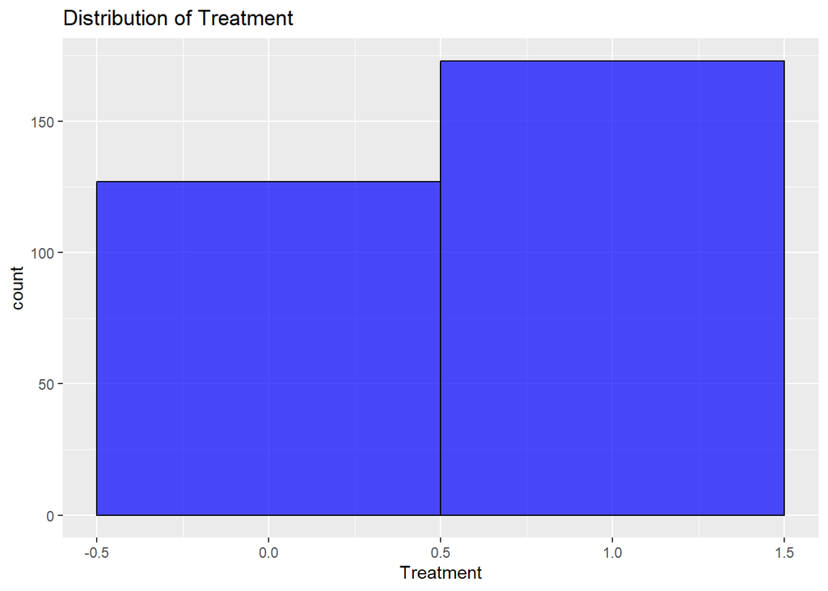

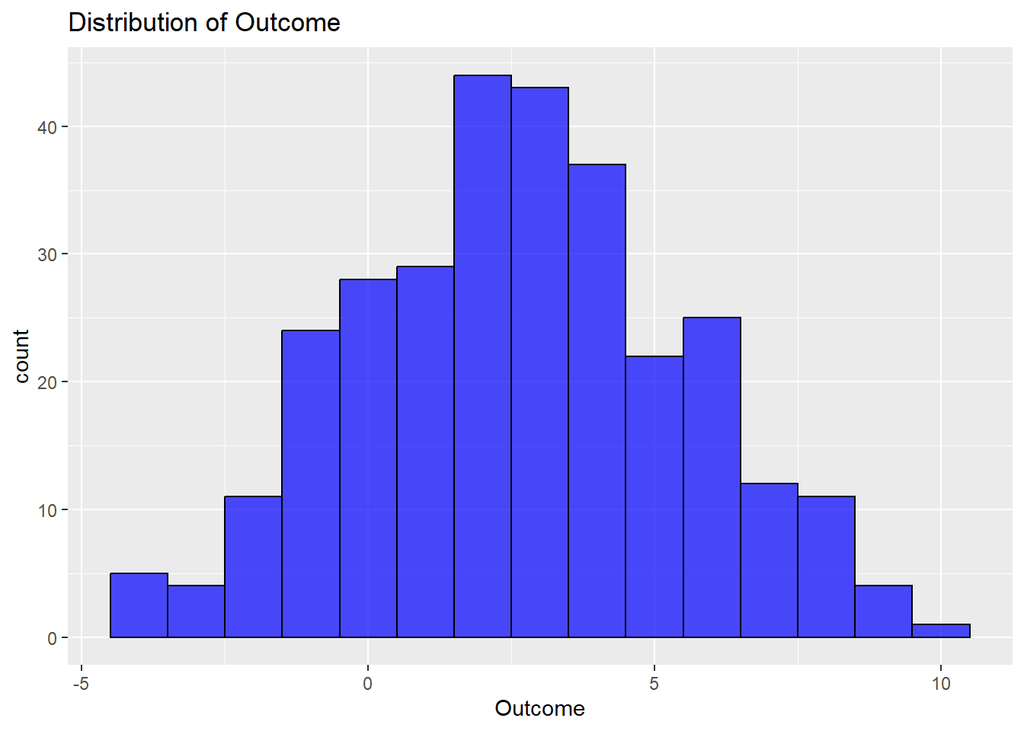

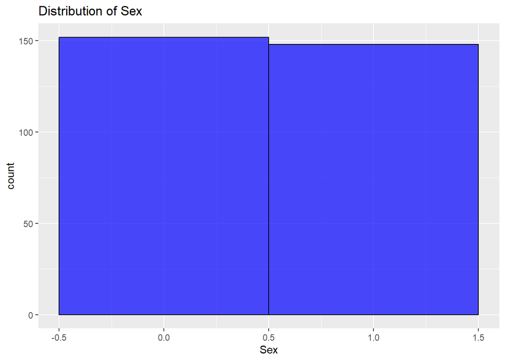

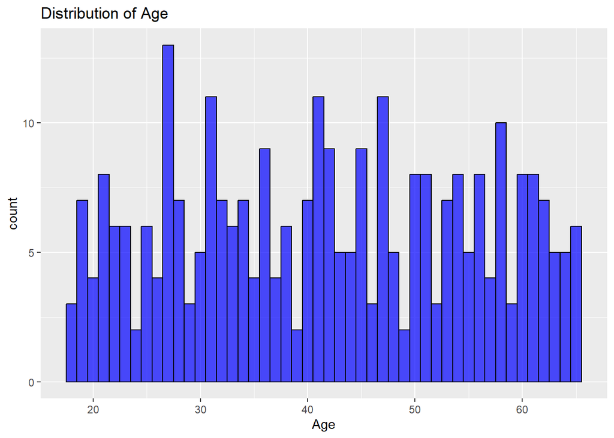

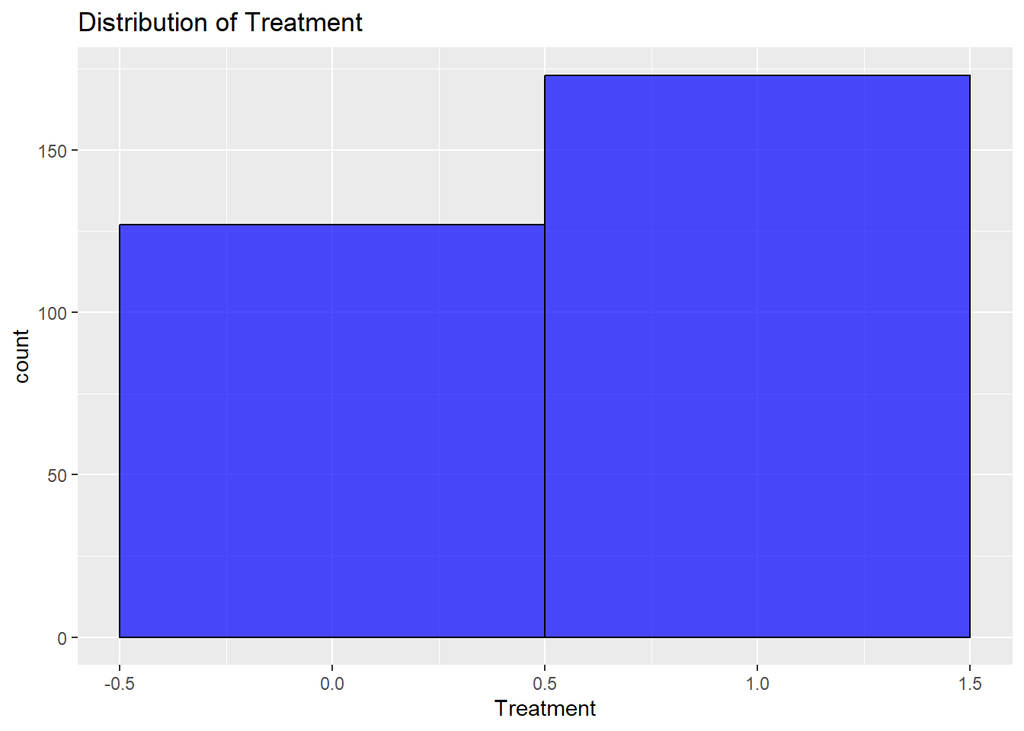

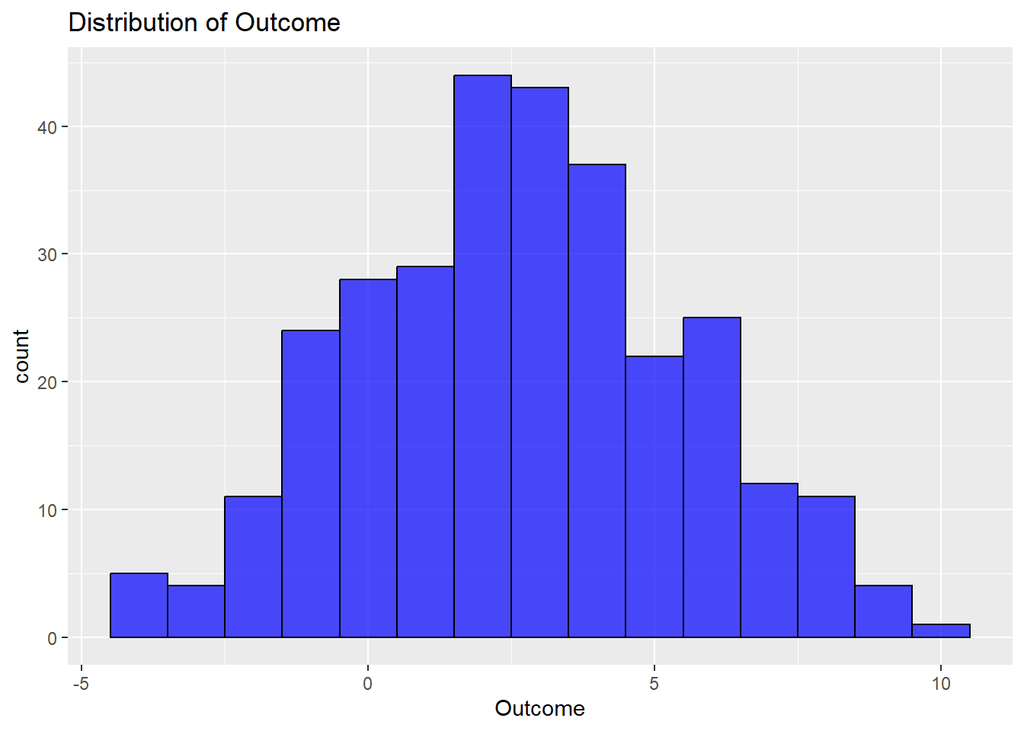

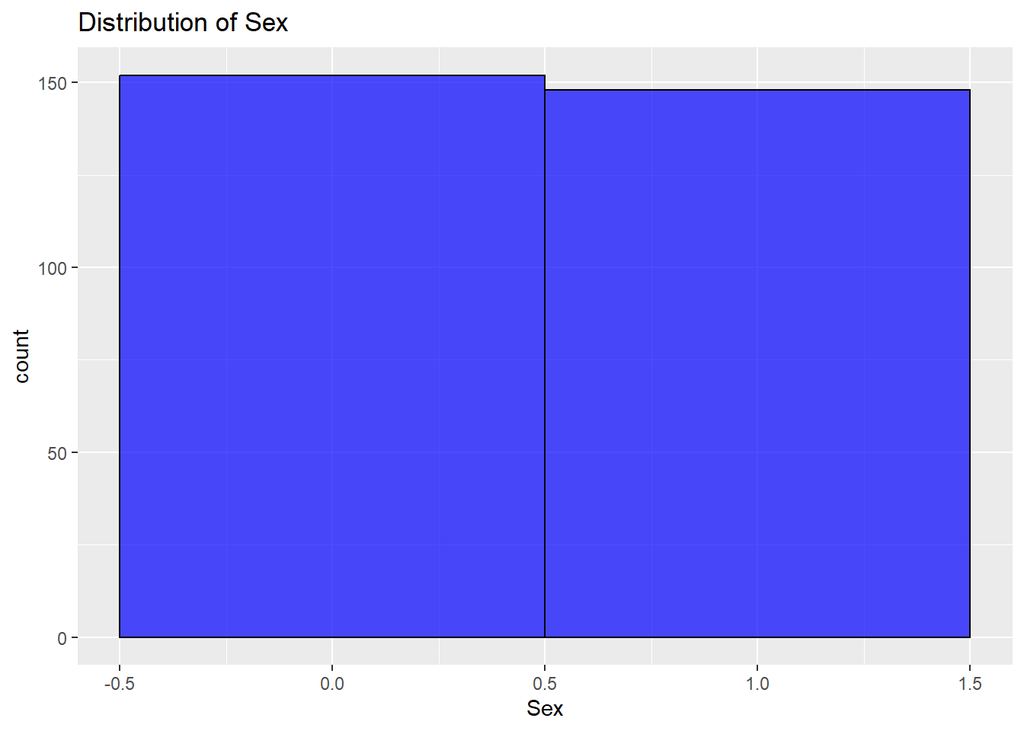

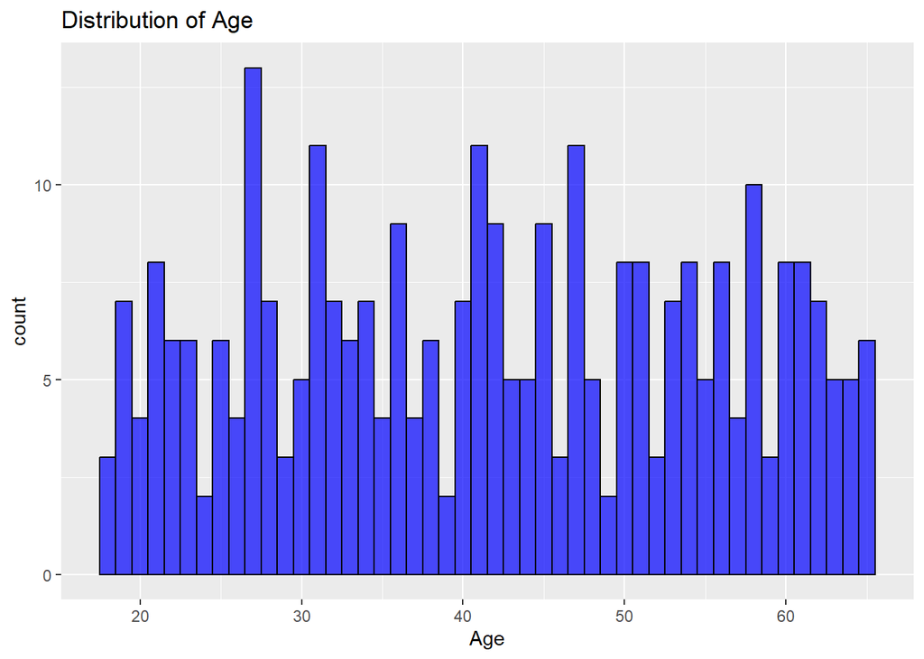

```r
# Histograms for numerical features
num_vars <- sapply(Example1$PhenoData, is.numeric)
data_numeric <- Example1$PhenoData[, num_vars]
lapply(names(data_numeric), function(var) {
  print(ggplot(Example1$PhenoData, aes_string(x = var)) +
        geom_histogram(binwidth = 1, fill = "blue", color = "black", alpha = 0.7) +
        labs(title = paste("Distribution of", var)))
})
```

```r
summary(Example1$PhenoData)
```

```
##    Treatment         Outcome             Sex              Age
##  Min.   :0.0000   Min.   :-4.4801   Min.   :0.0000   Min.   :18.00
##  1st Qu.:0.0000   1st Qu.: 0.5555   1st Qu.:0.0000   1st Qu.:31.00
##  Median :1.0000   Median : 2.6883   Median :0.0000   Median :42.00
##  Mean   :0.5767   Mean   : 2.6448   Mean   :0.4933   Mean   :41.85
##  3rd Qu.:1.0000   3rd Qu.: 4.4818   3rd Qu.:1.0000   3rd Qu.:54.00
##  Max.   :1.0000   Max.   : 9.9327   Max.   :1.0000   Max.   :65.00
```

**Treatment**: A binary feature that indicates the presence of the treatment for a test subject. **1** indicated the presence of the treatment. **0** indicates the absence of the treatment.

**Outcome**: A continuous numerical feature with unknown units of measurement.

**Sex**: A binary feature that indicates the biological sex of the subject. **1** indicates females, and **0** indicates males.

**Age**: A continuous numerical features that represents the age of the subject in years.

Categorical Features

```r
# Bar plots for categorical features
cat_vars <- sapply(Example1$PhenoData, is.factor)
data_categorical <- Example1$PhenoData[, cat_vars, drop = FALSE]
lapply(names(data_categorical), function(var) {
  print(ggplot(Example1$PhenoData, aes_string(x = var)) +
        geom_bar(fill = "blue", color = "black", alpha = 0.7) +
        labs(title = paste("Frequency of", var)))
})
```

```
## list()
```

### Example 1 Prediction Model

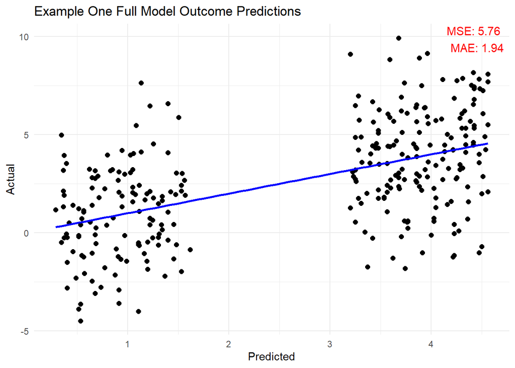

```r
Example1pl <- plot_examples(data = himaDat$Example1$PhenoData,
                                                   plotname = "Example One Full Model Outcome Predictions")
Example1pl
```

Clearly, the presence of treatment in conjunction with covariates do not accurately describe the relationship treatment has towards the outcome in Example 1. Mediation analysis is necessary to correct this.

### Mediation Analysis with classicHIMA

#### Mediator Identification

```r
hima.fit <- classicHIMA(
  X = himaDat$Example1$PhenoData$Treatment,
  Y = himaDat$Example1$PhenoData$Outcome,
  M = himaDat$Example1$Mediator,
  COV.XM = himaDat$Example1$PhenoData[, c("Sex", "Age")],
  Y.type = "continuous",
  scale = FALSE, # Disabled only for simulation data
  verbose = TRUE
)
```

```
## Running linear HIMA with MCP penalty...
```

```
## Step 1: Sure Independent Screening ...     (3:04:01 PM)
```

```
##     Screening M using the association between M (independent variable) and Y (dependent variable):     Adjusting for covariate(s): Sex, Age
##     Running Sure Independent Screening (Y ~ M + X + COV.MY, family: continuous) with single core...   (3:04:01 PM)
##     Top 106 mediators are selected: M1, M3, M2, M161, M105, M86, M16, M119, M202, M91, M181, M9, M39, M32, M30, M275, M62, M98, M41, M37, M38, M203, M222, M199, M21, M25, M87, M294, M243, M284, M175, M17, M109, M297, M151, M231, M128, M210, M117, M34, M49, M163, M190, M121, M217, M155, M125, M103…
## Step 2: Penalized estimate (MCP) ...     (3:04:01 PM)
##     Adjusting for covariate(s): Sex, Age
##     Tuning parameter lambda selected: 0.279040802377992
##     Non-zero MCP beta estimate(s) of mediator(s) found: M1,M2,M3
##     Estimating alpha (effect of X on M):     Adjusting for covariate(s): Sex, Age
##     Running site-by-site alpha estimation (M ~ X + COV.XM, family: gaussian) with single core...   (3:04:01 PM)
## Step 3: Joint significance test ...     (3:04:01 PM)
## Done!     (3:04:01 PM)
```

```r
hima.fit
```

```
##    Index  alpha_hat   beta_hat       IDE     rimp         pmax
## M1    M1  0.5771873  0.8917198 0.5146893 28.09267 1.614870e-03
## M2    M2  0.9137393  0.8461100 0.7731240 42.19850 1.093307e-08
## M3    M3 -0.7331281 -0.7424343 0.5442994 29.70884 6.210954e-05
```

```r
summary(Example1$Mediator[,hima.fit[,"Index"]])
```

```
##        M1                M2                  M3
##  Min.   :-2.6848   Min.   :-2.967920   Min.   :-4.1503
##  1st Qu.:-0.1890   1st Qu.:-0.003495   1st Qu.:-1.3377
##  Median : 0.8665   Median : 0.833371   Median :-0.2296
##  Mean   : 0.9068   Mean   : 0.899701   Mean   :-0.1922
##  3rd Qu.: 1.9467   3rd Qu.: 1.680141   3rd Qu.: 0.8739
##  Max.   : 5.7642   Max.   : 5.462254   Max.   : 4.9475
```

M1, M2, and M3 have been identified as the top three most significant mediator variables. (p < 0.05)

**alpha_hat** represents the effect the treatment has on the mediators.

**beta_hat** represents the effect the mediators have towards the outcome.

**IDE** stands for “Indirect Effect”, and is the result of **alpha_hat*beta_hat**.

**rimp** stands for “Relative Importance” and represents the average percent contribution a mediator has towards the net Indirect Effect.

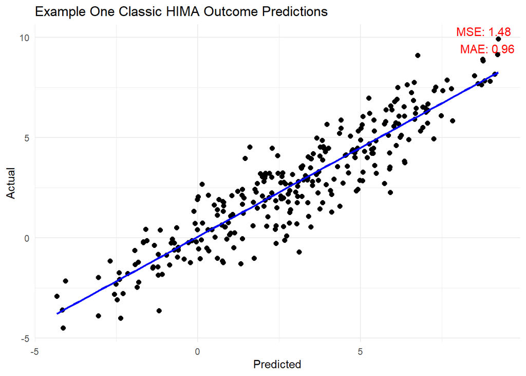

```r
E1classic <- estimatedEffects()
Example1classicmodelpl <- plot_mediator_adjustments(actual = himaDat$Example1$PhenoData$Outcome,
                                        estimations = E1classic,
                                        mediator_indices = hima.fit[,"Index"],
                                        plotname = "Example One Classic HIMA Outcome Predictions")
Example1classicmodelpl
```

The consideration of mediators allows the relationship between Treatment and Outcome to be much more accurately described.

The contribution towards the outcome by each mediator is calculated as **M * beta_hat.**

The contribution towards the outcome by the Direct Effect is calculated as the **E(Y | X, Cov) - IDE**.

The mediator adjusted prediction is **E(Y | X, M, Cov) = 𝛽*M + E(Y | X, Cov) - IDE**.

#### Effect Analysis

##### Test for Normality

*H<sub>0</sub>* : The values for every type of measured effect are drawn from the normal distribution.

*H<sub>1</sub>* : The values for every type of measured effect are drawn from outside the normal distribution.

```r
E1_classic_control_ks_results <- kstests(dat = E1classic[E1classic$Treatment == 0,], exclude = c("Treatment","Sex","Other", "DominantEffect", "Direct"))
```

```
## [1] "Outcome"   "Age"       "M1"        "M2"        "M3"        "Residuals"
## [7] "Adjusted"
```

```r
print(data.frame(E1_classic_control_ks_results))
```

```
##           D_Statistic       P_Value
## Outcome     0.3723868  1.009306e-15
## Age         1.0000000 9.777585e-111
## M1          0.2194817  9.707694e-06
## M2          0.1324823  2.316869e-02
## M3          0.1038529  1.291706e-01
## Residuals   0.1458297  9.018351e-03
## Adjusted    0.3054095  1.027533e-10
```

```r
E1_classic_experimental_ks_results <- kstests(dat = E1classic[E1classic$Treatment != 0,], exclude = c("Treatment","Sex","Other", "DominantEffect", "Direct"))
```

```
## [1] "Outcome"   "Age"       "M1"        "M2"        "M3"        "Residuals"
## [7] "Adjusted"
```

```r
print(data.frame(E1_classic_experimental_ks_results))
```

```
##           D_Statistic       P_Value
## Outcome     0.7812265  3.904117e-92
## Age         1.0000000 1.084275e-150
## M1          0.3824018  2.125567e-22
## M2          0.3920301  1.610761e-23
## M3          0.1761101  4.370890e-05
## Residuals   0.2722779  1.448861e-11
## Adjusted    0.8741880 2.931807e-115
```

##### Tests for Correlation

We reject *H<sub>0</sub>* (p < 0.05). In rejection of the null hypothesis, we shall test for whether there exists correlations between each mediator effect.

*H<sub>0</sub>* : There exists no correlation between a mediator effect and any other mediator effect.

*H<sub>1</sub>* : There exists a correlation between an effect and any other mediator effect.

```r
E1classic_effect_cor <- perform_cor_tests(E1classic, c(hima.fit[,"Index"]), alternative = "two.sided", method = "spearman")
E1classic_effect_cor
```

```
## $`M1 - M2`
##
##  Spearman's rank correlation rho
##
## data:  data[, x[i]] and data[, x[j]]
## S = 4302282, p-value = 0.4482
## alternative hypothesis: true rho is not equal to 0
## sample estimates:
##        rho
## 0.04392671
##
##
## $`M1 - M3`
##
##  Spearman's rank correlation rho
##
## data:  data[, x[i]] and data[, x[j]]
## S = 3935150, p-value = 0.0298
## alternative hypothesis: true rho is not equal to 0
## sample estimates:
##       rho
## 0.1255125
##
##
## $`M2 - M3`
##
##  Spearman's rank correlation rho
##
## data:  data[, x[i]] and data[, x[j]]
## S = 4291470, p-value = 0.4238
## alternative hypothesis: true rho is not equal to 0
## sample estimates:
##       rho
## 0.0463294
```

We cannot reject the null hypothesis(adjusted p > 0.05). We will follow up on this by testing for the correlation between each effect for the experimental group. where the direct effect is always present.

*H<sub>0</sub>* : There exists no correlation between an effect and any other effect in the experimental group.

*H<sub>1</sub>* : There exists a correlation between an effect and any other effect in the experimental group.

```r
E1classic_effect_cor_e <- perform_cor_tests(E1classic[E1classic$Treatment > 0,], c(hima.fit[,"Index"], "Direct"), alternative = "two.sided", method = "spearman")
E1classic_effect_cor_e
```

```
## $`M1 - M2`
##
##  Spearman's rank correlation rho
##
## data:  data[, x[i]] and data[, x[j]]
## S = 888636, p-value = 0.6969
## alternative hypothesis: true rho is not equal to 0
## sample estimates:
##         rho
## -0.02979637
##
##
## $`M1 - M3`
##
##  Spearman's rank correlation rho
##
## data:  data[, x[i]] and data[, x[j]]
## S = 782292, p-value = 0.2212
## alternative hypothesis: true rho is not equal to 0
## sample estimates:
##        rho
## 0.09344044
##
##
## $`M1 - Direct`
##
##  Spearman's rank correlation rho
##
## data:  data[, x[i]] and data[, x[j]]
## S = 741518, p-value = 0.06485
## alternative hypothesis: true rho is not equal to 0
## sample estimates:
##       rho
## 0.1406912
##
##
## $`M2 - M3`
##
##  Spearman's rank correlation rho
##
```

[output cut: 15 more lines]

```
## sample estimates:
##       rho
## 0.2300385
##
##
## $`M3 - Direct`
##
##  Spearman's rank correlation rho
##
## data:  data[, x[i]] and data[, x[j]]
## S = 1049058, p-value = 0.00437
## alternative hypothesis: true rho is not equal to 0
## sample estimates:
##        rho
## -0.2157013
```

We reject the null hypothesis: There exists positive correlation between M2 and the Direct Effect (adjusted p < 0.05). There exists negative correlation between M3 and the Direct Effect. For the relationships between each mediator effect, the null hypothesis cannot be rejected. We will conduct bootstrap sampling to find the true mean of each effect in the control group and experimental group.

```r
E1classic_control_long <- melt(E1classic[E1classic$Treatment == 0,hima.fit[,"Index"]], variable.name = "Effect", value.name = "Contribution")
head(E1classic_control_long)
```

```
##   Effect Contribution
## 1     M1    1.8906235
## 2     M1    1.2769382
## 3     M1    3.1001455
## 4     M1    1.2200287
## 5     M1   -0.2755782
## 6     M1   -1.2722884
```

```r
E1_classic_control_pl <- plot_violins(E1classic_control_long, x = "Effect", y = "Contribution", "Example 1 Classic HIMA Control Group Effects")
E1classic_control_boot <- boot_tests(data = E1classic_control_long, x = "Effect", y = "Contribution", statistic = mean)
E1classic_control_boot
```

```
##          2.5%      97.5%
## M1  0.2572765 0.77570505
## M2  0.1292527 0.49481892
## M3 -0.3807642 0.02820888
```

```r
E1classic_experimental_long <- melt(E1classic[E1classic$Treatment != 0,c(hima.fit[,"Index"], "Direct")], variable.name = "Effect", value.name = "Contribution")
head(E1classic_experimental_long)
```

```
##   Effect Contribution
## 1     M1  -2.02603089
## 2     M1  -0.08914961
## 3     M1   0.36942663
## 4     M1   2.02882904
## 5     M1  -0.23360610
## 6     M1   1.04456606
```

```r
E1classic_experimental_pl <- plot_violins(E1classic_experimental_long, x = "Effect", y = "Contribution", "Example 1 Classic HIMA Experimental Group Effects")
E1classic_experimental_boot <- boot_tests(data = E1classic_experimental_long, x = "Effect", y = "Contribution", statistic = mean)
E1classic_experimental_boot
```

```
##             2.5%    97.5%
## M1     0.8497558 1.218627
## M2     0.9190842 1.264347
## M3     0.2088211 0.536470
## Direct 2.0042819 2.126132
```

In the experimental group, the mean contributions of each effect are much higher than they are in the control group.

We are going to test for correlations between effects and the measured outcome and residuals of the mediator adjusted prediction to the measured outcome.

*H<sub>0</sub>* : There exists no correlation between any effect and measured outcome in the experimental group.

*H<sub>1</sub>* : There exists a correlation between any effect and measured outcome in the experimental group.

```r
E1classic_effect_outcome_cor <- perform_cor_tests(E1classic, x = c(hima.fit[,"Index"], "Direct", "Residuals"), y = "Outcome", alternative = "two.sided", method = "spearman")
E1classic_effect_outcome_cor
```

```
## $`M1 - Outcome`
##
##  Spearman's rank correlation rho
##
## data:  data[, name] and data[, y]
## S = 1799762, p-value < 2.2e-16
## alternative hypothesis: true rho is not equal to 0
## sample estimates:
##       rho
## 0.6000484
##
##
## $`M2 - Outcome`
##
##  Spearman's rank correlation rho
##
## data:  data[, name] and data[, y]
## S = 2191026, p-value < 2.2e-16
## alternative hypothesis: true rho is not equal to 0
## sample estimates:
##       rho
## 0.5130999
##
##
## $`M3 - Outcome`
##
##  Spearman's rank correlation rho
##
## data:  data[, name] and data[, y]
## S = 2170348, p-value < 2.2e-16
## alternative hypothesis: true rho is not equal to 0
## sample estimates:
##       rho
## 0.5176951
##
##
## $`Direct - Outcome`
##
##  Spearman's rank correlation rho
##
## data:  data[, name] and data[, y]
## S = 2198449, p-value < 2.2e-16
## alternative hypothesis: true rho is not equal to 0
## sample estimates:
##       rho
## 0.5114504
##
##
## $`Residuals - Outcome`
##
##  Spearman's rank correlation rho
##
## data:  data[, name] and data[, y]
## S = 4005596, p-value = 0.05739
## alternative hypothesis: true rho is not equal to 0
## sample estimates:
##       rho
## 0.1098577
```

We can reject the null hypothesis(adjusted p < 0.05). For all effects, there exists positive correlation to the outcome. The residuals of the model do not show strong correlation with the Outcome, indicating that it is unlikely for magnitude of outcome to be a limiting factor in the accuracy of effect contributions. We will move on to testing the correlation the effects and residuals have to the Age of the subjects.

*H<sub>0</sub>* : There exists no correlation between any effect and age in the experimental group.

*H<sub>1</sub>* : There exists a correlation between any effect and age in the experimental group.

```r
E1classic_effect_age_cor <- perform_cor_tests(E1classic, x = c(hima.fit[,"Index"], "Direct", "Residuals"), y = "Age", alternative = "two.sided", method = "spearman")
E1classic_effect_age_cor
```

```
## $`M1 - Age`
##
##  Spearman's rank correlation rho
##
## data:  data[, name] and data[, y]
## S = 3899019, p-value = 0.02068
## alternative hypothesis: true rho is not equal to 0
## sample estimates:
##       rho
## 0.1335417
##
##
## $`M2 - Age`
##
##  Spearman's rank correlation rho
##
## data:  data[, name] and data[, y]
## S = 3669834, p-value = 0.00133
## alternative hypothesis: true rho is not equal to 0
## sample estimates:
##       rho
## 0.1844723
##
##
## $`M3 - Age`
##
##  Spearman's rank correlation rho
##
## data:  data[, name] and data[, y]
## S = 5112951, p-value = 0.01824
## alternative hypothesis: true rho is not equal to 0
## sample estimates:
##       rho
## -0.136224
##
##
## $`Direct - Age`
##
##  Spearman's rank correlation rho
##
## data:  data[, name] and data[, y]
## S = 2763221, p-value = 4.297e-12
## alternative hypothesis: true rho is not equal to 0
## sample estimates:
##       rho
## 0.3859442
##
##
## $`Residuals - Age`
##
##  Spearman's rank correlation rho
##
## data:  data[, name] and data[, y]
## S = 4640491, p-value = 0.59
## alternative hypothesis: true rho is not equal to 0
## sample estimates:
##        rho
## -0.0312317
```

We can reject the null hypothesis(adjusted p < 0.05). M2 and the direct effect have positive correlation to the age. These results suggest that age of the subject affects their sensitivity to the effects of each mediator. The correlation between Age and the residuals of the mediator adjusted model do not have statistical significance, suggesting that the age of the subject does not strongly influence the model’s inaccuracies.

##### Test for differences across groups

We are going to use the Kruskal-Wallis test to determine the difference in variance for effects, residuals, and the outcome across sexes.

*H<sub>0</sub>* : There exists no difference in medians in any effects and the outcome across male and female subjects.

*H<sub>1</sub>* : There exists a difference in medians in any effects and the outcome across male and female subjects.

```r
E1classic_kruskal_sex <- perform_kruskal(E1classic, "Sex", c(hima.fit[,"Index"], "Direct", "Outcome", "Residuals"))
```

```
## [1] "M1"
## [1] "M2"
## [1] "M3"
## [1] "Direct"
## [1] "Outcome"
## [1] "Residuals"
```

```r
E1classic_kruskal_sex
```

```
## $M1
##
##  Kruskal-Wallis rank sum test
##
## data:  y_val by x_val
## Kruskal-Wallis chi-squared = 0.21958, df = 1, p-value = 0.6394
##
##
## $M2
##
##  Kruskal-Wallis rank sum test
##
## data:  y_val by x_val
## Kruskal-Wallis chi-squared = 0.19416, df = 1, p-value = 0.6595
##
##
## $M3
##
##  Kruskal-Wallis rank sum test
##
## data:  y_val by x_val
## Kruskal-Wallis chi-squared = 4.0034, df = 1, p-value = 0.04541
##
##
## $Direct
##
##  Kruskal-Wallis rank sum test
##
## data:  y_val by x_val
## Kruskal-Wallis chi-squared = 0.0030685, df = 1, p-value = 0.9558
##
##
## $Outcome
##
##  Kruskal-Wallis rank sum test
##
## data:  y_val by x_val
## Kruskal-Wallis chi-squared = 0.048834, df = 1, p-value = 0.8251
##
##
## $Residuals
##
##  Kruskal-Wallis rank sum test
##
## data:  y_val by x_val
## Kruskal-Wallis chi-squared = 0.77431, df = 1, p-value = 0.3789
```

The null hypothesis cannot be rejected(adjusted p > 0.05). The difference in variance in residuals in male subjects and female subjects is statistically insignificant, suggesting that the sex of the patient is not a limiting factor in the accuracy of the model.

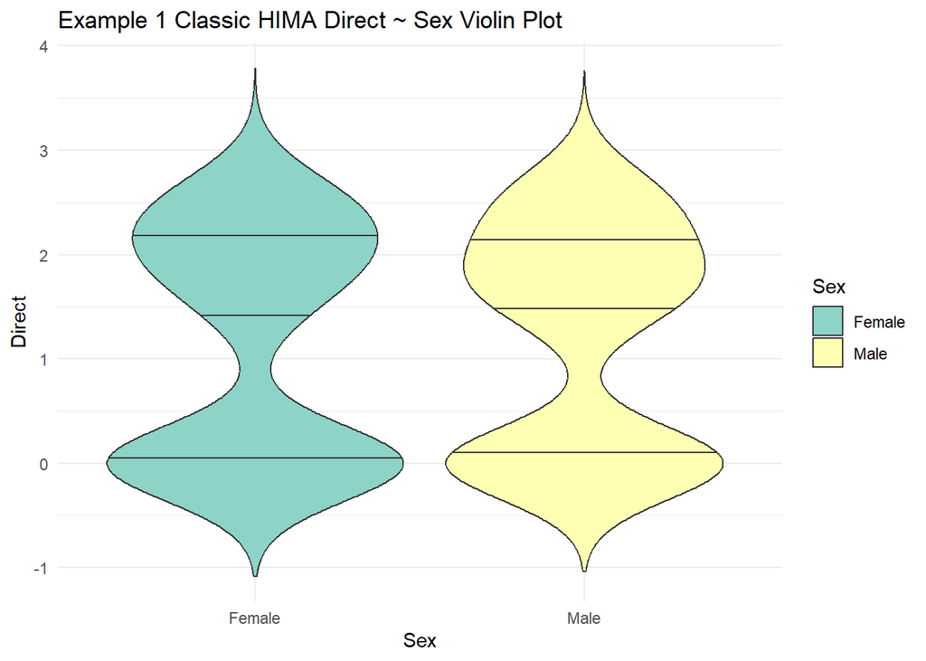

```r
E1classic$Sex <- ifelse(E1classic$Sex == 0, "Male", "Female")
E1classic_sex_pl <- plot_violins(E1classic, "Sex", "Direct", plotname = "Example 1 Classic HIMA Direct ~ Sex Violin Plot")
E1classic_sex_pl
```

```r
boot_tests(E1classic, "Sex", "Direct", mean)
```

```
##             2.5%    97.5%
## Male   1.0502034 1.383361
## Female 0.9946853 1.333353
```

##### Findings

The results of **classicHIMA** for Example 1 show:

M2 has positive correlation with the direct effect. M3 has negative correlation with the direct effect.

All effects have a positive correlation with the outcome.

The direct effect and M2 have positive correlation with age.

The residuals cannot be attributed to the input data as a limiting factor.

### Mediation Analysis with dblassoHIMA

#### Mediator Identification

```r
dblassohima.fit <- dblassoHIMA(
  X = himaDat$Example1$PhenoData$Treatment,
  Y = himaDat$Example1$PhenoData$Outcome,
  M = himaDat$Example1$Mediator,
  COV = himaDat$Example1$PhenoData[, c("Sex", "Age")],
  scale = FALSE, # Disabled only for simulation data
  FDRcut = 0.05,
  verbose = TRUE
)
```

```
## Step 1: Sure Independent Screening ...  (3:04:02 PM)
```

```
##         Top 106 mediators are selected: M1, M2, M3, M6, M7, M12, M13, M14, M16, M17, M21, M22, M29, M30, M31, M32, M34, M37, M40, M41, M48, M49, M50, M58, M60, M61, M62, M66, M68, M74, M76, M78, M82, M83, M84, M86, M87, M89, M91, M96, M97, M98, M103, M105, M109, M116, M117, M119, M120, M122, M125…
```

```
## Step 2: De-biased Lasso Estimates ...   (3:04:02 PM)
```

```
##         Adjusting for covariate(s): Sex, Age
```

```
## Step 3: Joint significance test ...     (3:04:11 PM)
```

```
##         3 significant mediator(s) identified.
```

```
## Done!     (3:04:11 PM)
```

```r
dblassohima.fit
```

```
##    Index  alpha_hat  alpha_se   beta_hat    beta_se       IDE     rimp
## M1    M1  0.5771873 0.1813573  0.9316032 0.04252103 0.5377095 28.40599
## M2    M2  0.9137393 0.1553407  0.8842992 0.04804286 0.8080189 42.68583
## M3    M3 -0.7331281 0.1804393 -0.7464121 0.04210577 0.5472157 28.90818
##            pmax
## M1 1.459604e-03
## M2 4.049412e-09
## M3 4.844242e-05
```

```r
E1dblasso <- estimatedEffects(fit = dblassohima.fit)
summary(Example1$Mediator[,dblassohima.fit[,"Index"]])
```

```
##        M1                M2                  M3
##  Min.   :-2.6848   Min.   :-2.967920   Min.   :-4.1503
##  1st Qu.:-0.1890   1st Qu.:-0.003495   1st Qu.:-1.3377
##  Median : 0.8665   Median : 0.833371   Median :-0.2296
##  Mean   : 0.9068   Mean   : 0.899701   Mean   :-0.1922
##  3rd Qu.: 1.9467   3rd Qu.: 1.680141   3rd Qu.: 0.8739
##  Max.   : 5.7642   Max.   : 5.462254   Max.   : 4.9475
```

**dblassoHIMA** differs from **classicHIMA** in that it repeatedly refines it’s estimates with debiased lasso, leading to a slow runtime.

M1, M2, and M3 have been identified as the top three most significant mediator variables. (p < 0.05)

**alpha_hat** represents the effect the treatment has on the mediators.

**beta_hat** represents the effect the mediators have towards the outcome.

**alpha_se** is the standard error for **E(M | X, Cov).**

**beta_se** is the standard error for **E(Y | M, Cov).**

**IDE** stands for “Indirect Effect”, and is the result of **alpha_hat*beta_hat**.

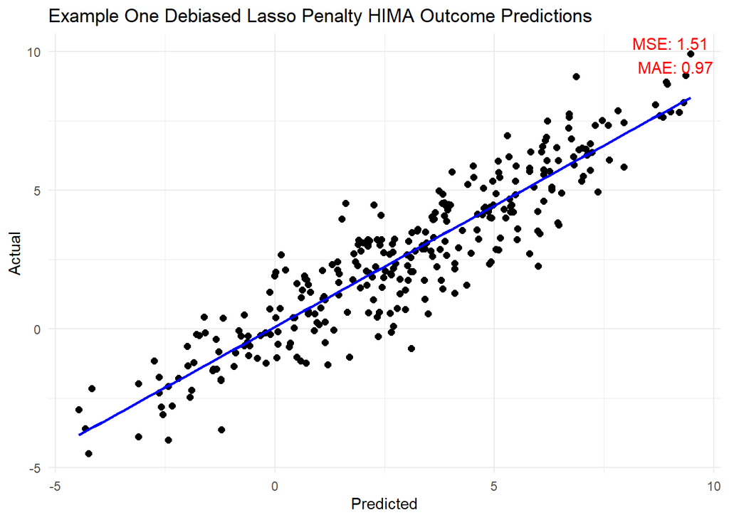

```r
E1dblasso <- estimatedEffects(fit = dblassohima.fit)
E1dblassopl <- plot_mediator_adjustments(actual = himaDat$Example1$PhenoData$Outcome,
                             estimations = E1dblasso,
                             mediator_indices = dblassohima.fit[,"Index"],
                             plotname = "Example One Debiased Lasso Penalty HIMA Outcome Predictions")
E1dblassopl
```

The consideration of mediators allows the relationship between Treatment and Outcome to be much more accurately described.

The contribution towards the outcome by each mediator is calculated as **M * beta_hat.**

The contribution towards the outcome by the Direct Effect is calculated as the **E(Y | X, Cov) - IDE**.

The mediator adjusted prediction is **E(Y | X, M, Cov) = 𝛽*M + E(Y | X, Cov) - IDE**.

#### Effect Analysis

##### Test for Normality

*H<sub>0</sub>* : The values for every type of measured effect are drawn from the normal distribution.

*H<sub>1</sub>* : The values for every type of measured effect are drawn from outside the normal distribution.

```r
E1dblasso_control_ks_results <- kstests(dat = E1dblasso[E1dblasso$Treatment == 0,], exclude = c("Treatment","Sex","Other", "DominantEffect", "Direct"))
```

```
## [1] "Outcome"   "Age"       "M1"        "M2"        "M3"        "Residuals"
## [7] "Adjusted"
```

```r
print(data.frame(E1dblasso_control_ks_results))
```

```
##           D_Statistic       P_Value
## Outcome     0.3723868  1.009306e-15
## Age         1.0000000 9.777585e-111
## M1          0.2294825  3.103250e-06
## M2          0.1308260  2.588275e-02
## M3          0.1049749  1.217133e-01
## Residuals   0.1231425  4.248792e-02
## Adjusted    0.3163136  1.836361e-11
```

```r
E1dblasso_experimental_ks_results <- kstests(dat = E1dblasso[E1dblasso$Treatment != 0,], exclude = c("Treatment","Sex","Other", "DominantEffect", "Direct"))
```

```
## [1] "Outcome"   "Age"       "M1"        "M2"        "M3"        "Residuals"
## [7] "Adjusted"
```

```r
print(data.frame(E1dblasso_experimental_ks_results))
```

```
##           D_Statistic       P_Value
## Outcome     0.7812265  3.904117e-92
## Age         1.0000000 1.084275e-150
## M1          0.3929732  1.246760e-23
## M2          0.4026911  8.588050e-25
## M3          0.1774003  3.732800e-05
## Residuals   0.2800821  3.260452e-12
## Adjusted    0.8727143 7.144715e-115
```

##### Tests for Correlation

We reject *H<sub>0</sub>* (p < 0.05). In rejection of the null hypothesis, we shall test for correlations between each mediator effect.

*H<sub>0</sub>* : There exists no correlation between a mediator effect and any other mediator effect.

*H<sub>1</sub>* : There exists a correlation between an effect and any other mediator effect.

```r
E1dblasso_effect_cor <- perform_cor_tests(E1dblasso, c(dblassohima.fit[,"Index"]), alternative = "two.sided", method = "spearman")
E1dblasso_effect_cor
```

```
## $`M1 - M2`
##
##  Spearman's rank correlation rho
##
## data:  data[, x[i]] and data[, x[j]]
## S = 4302282, p-value = 0.4482
## alternative hypothesis: true rho is not equal to 0
## sample estimates:
##        rho
## 0.04392671
##
##
## $`M1 - M3`
##
##  Spearman's rank correlation rho
##
## data:  data[, x[i]] and data[, x[j]]
## S = 3935150, p-value = 0.0298
## alternative hypothesis: true rho is not equal to 0
## sample estimates:
##       rho
## 0.1255125
##
##
## $`M2 - M3`
##
##  Spearman's rank correlation rho
##
## data:  data[, x[i]] and data[, x[j]]
## S = 4291470, p-value = 0.4238
## alternative hypothesis: true rho is not equal to 0
## sample estimates:
##       rho
## 0.0463294
```

We cannot reject the null hypothesis(adjusted p > 0.05). We will follow up on this by testing for the correlation between each effect for the experimental group, where the direct effect is always present.

*H<sub>0</sub>* : There exists no correlation between an effect and any other effect in the experimental group.

*H<sub>1</sub>* : There exists a correlation between an effect and any other effect in the experimental group.

```r
E1dblasso_effect_cor_e <- perform_cor_tests(E1dblasso[E1dblasso$Treatment > 0,], c(dblassohima.fit[,"Index"], "Direct"), alternative = "two.sided", method = "spearman")
E1dblasso_effect_cor_e
```

```
## $`M1 - M2`
##
##  Spearman's rank correlation rho
##
## data:  data[, x[i]] and data[, x[j]]
## S = 888636, p-value = 0.6969
## alternative hypothesis: true rho is not equal to 0
## sample estimates:
##         rho
## -0.02979637
##
##
## $`M1 - M3`
##
##  Spearman's rank correlation rho
##
## data:  data[, x[i]] and data[, x[j]]
## S = 782292, p-value = 0.2212
## alternative hypothesis: true rho is not equal to 0
## sample estimates:
##        rho
## 0.09344044
##
##
## $`M1 - Direct`
##
##  Spearman's rank correlation rho
##
## data:  data[, x[i]] and data[, x[j]]
## S = 741518, p-value = 0.06485
## alternative hypothesis: true rho is not equal to 0
## sample estimates:
##       rho
## 0.1406912
##
##
## $`M2 - M3`
##
##  Spearman's rank correlation rho
##
```

[output cut: 15 more lines]

```
## sample estimates:
##       rho
## 0.2300385
##
##
## $`M3 - Direct`
##
##  Spearman's rank correlation rho
##
## data:  data[, x[i]] and data[, x[j]]
## S = 1049058, p-value = 0.00437
## alternative hypothesis: true rho is not equal to 0
## sample estimates:
##        rho
## -0.2157013
```

We reject the null hypothesis: There exists positive correlation between M2 and the Direct Effect (adjusted p < 0.05). There exists negative correlation between M3 and the Direct Effect(adjusted p < 0.05). For the relationships between each mediator effect, the null hypothesis cannot be rejected. We will conduct bootstrap sampling to find the true mean of each effect in the control group and experimental group.

```r
E1dblasso_control_long <- melt(E1dblasso[E1dblasso$Treatment == 0,hima.fit[,"Index"]], variable.name = "Effect", value.name = "Contribution")
head(E1dblasso_control_long)
```

```
##   Effect Contribution
## 1     M1    1.9751841
## 2     M1    1.3340509
## 3     M1    3.2388035
## 4     M1    1.2745961
## 5     M1   -0.2879038
## 6     M1   -1.3291931
```

```r
E1dblasso_control_pl <- plot_violins(E1dblasso_control_long, x = "Effect", y = "Contribution", "Example 1 Debiased Lasso HIMA Control Group Effects")
E1dblasso_control_boot <- boot_tests(data = E1dblasso_control_long, x = "Effect", y = "Contribution", statistic = mean)
E1dblasso_control_boot
```

```
##          2.5%      97.5%
## M1  0.2670025 0.80561441
## M2  0.1460786 0.51591243
## M3 -0.3883480 0.03106937
```

```r
E1dblasso_experimental_long <- melt(E1dblasso[E1dblasso$Treatment != 0,c(dblassohima.fit[,"Index"], "Direct")], variable.name = "Effect", value.name = "Contribution")
head(E1dblasso_experimental_long)
```

```
##   Effect Contribution
## 1     M1  -2.11664776
## 2     M1  -0.09313694
## 3     M1   0.38594972
## 4     M1   2.11957106
## 5     M1  -0.24405443
## 6     M1   1.09128564
```

```r
E1dblasso_experimental_pl <- plot_violins(E1dblasso_experimental_long, x = "Effect", y = "Contribution", "Example 1 Debiased Lasso HIMA Experimental Group Effects")
E1dblasso_experimental_boot <- boot_tests(data = E1dblasso_experimental_long, x = "Effect", y = "Contribution", statistic = mean)
E1dblasso_experimental_boot
```

```
##             2.5%     97.5%
## M1     0.8745751 1.2811886
## M2     0.9579312 1.3375284
## M3     0.2110723 0.5449022
## Direct 1.9489599 2.0631885
```

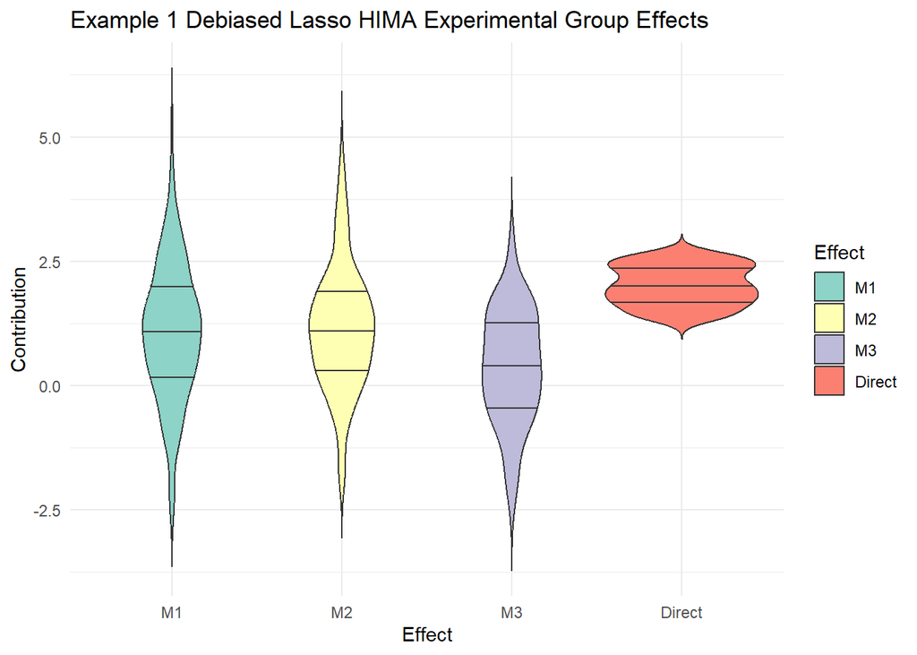

```r
E1dblasso_experimental_pl
```

In the experimental group, the mean contributions of each effect are much higher than they are in the control group.

We are going to test for correlations between effects and the measured outcome and residuals of the mediator adjusted prediction to the measured outcome.

*H<sub>0</sub>* : There exists no correlation between any effect and measured outcome in the experimental group.

*H<sub>1</sub>* : There exists a correlation between any effect and measured outcome in the experimental group.

```r
E1dblasso_effect_outcome_cor <- perform_cor_tests(E1dblasso, x = c(dblassohima.fit[,"Index"], "Direct", "Residuals"), y = "Outcome", alternative = "two.sided", method = "spearman")
E1dblasso_effect_outcome_cor
```

```
## $`M1 - Outcome`
##
##  Spearman's rank correlation rho
##
## data:  data[, name] and data[, y]
## S = 1799762, p-value < 2.2e-16
## alternative hypothesis: true rho is not equal to 0
## sample estimates:
##       rho
## 0.6000484
##
##
## $`M2 - Outcome`
##
##  Spearman's rank correlation rho
##
## data:  data[, name] and data[, y]
## S = 2191026, p-value < 2.2e-16
## alternative hypothesis: true rho is not equal to 0
## sample estimates:
##       rho
## 0.5130999
##
##
## $`M3 - Outcome`
##
##  Spearman's rank correlation rho
##
## data:  data[, name] and data[, y]
## S = 2170348, p-value < 2.2e-16
## alternative hypothesis: true rho is not equal to 0
## sample estimates:
##       rho
## 0.5176951
##
##
## $`Direct - Outcome`
##
##  Spearman's rank correlation rho
##
## data:  data[, name] and data[, y]
## S = 2198449, p-value < 2.2e-16
## alternative hypothesis: true rho is not equal to 0
## sample estimates:
##       rho
## 0.5114504
##
##
## $`Residuals - Outcome`
##
##  Spearman's rank correlation rho
##
## data:  data[, name] and data[, y]
## S = 4204784, p-value = 0.2572
## alternative hypothesis: true rho is not equal to 0
## sample estimates:
##        rho
## 0.06559317
```

We can reject the null hypothesis(adjusted p < 0.05). For all effects, there exists positive correlation to the outcome. The residuals of the model do not show strong correlation with the Outcome, indicating that it is unlikely for magnitude of outcome to be a limiting factor in the accuracy of effect contributions. We will move on to testing the correlation the effects and residuals have to the Age of the subjects.

*H<sub>0</sub>* : There exists no correlation between any effect and age in the experimental group.

*H<sub>1</sub>* : There exists a correlation between any effect and age in the experimental group.

```r
E1dblasso_effect_age_cor <- perform_cor_tests(E1dblasso, x = c(dblassohima.fit[,"Index"], "Direct", "Residuals"), y = "Age", alternative = "two.sided", method = "spearman")
E1dblasso_effect_age_cor
```

```
## $`M1 - Age`
##
##  Spearman's rank correlation rho
##
## data:  data[, name] and data[, y]
## S = 3899019, p-value = 0.02068
## alternative hypothesis: true rho is not equal to 0
## sample estimates:
##       rho
## 0.1335417
##
##
## $`M2 - Age`
##
##  Spearman's rank correlation rho
##
## data:  data[, name] and data[, y]
## S = 3669834, p-value = 0.00133
## alternative hypothesis: true rho is not equal to 0
## sample estimates:
##       rho
## 0.1844723
##
##
## $`M3 - Age`
##
##  Spearman's rank correlation rho
##
## data:  data[, name] and data[, y]
## S = 5112951, p-value = 0.01824
## alternative hypothesis: true rho is not equal to 0
## sample estimates:
##       rho
## -0.136224
##
##
## $`Direct - Age`
##
##  Spearman's rank correlation rho
##
## data:  data[, name] and data[, y]
## S = 2763221, p-value = 4.297e-12
## alternative hypothesis: true rho is not equal to 0
## sample estimates:
##       rho
## 0.3859442
##
##
## $`Residuals - Age`
##
##  Spearman's rank correlation rho
##
## data:  data[, name] and data[, y]
## S = 4704008, p-value = 0.4339
## alternative hypothesis: true rho is not equal to 0
## sample estimates:
##         rho
## -0.04534671
```

We can reject the null hypothesis(p < 0.05). For all effects, there is statistical significance to age. M2 and the direct effect have positive correlation with age. These results suggest that age of the subject affects their sensitivity to the effects of each mediator. The correlation between Age and the residuals of the mediator adjusted model do not have statistical significance, suggesting that the age of the subject does not strongly influence the model’s inaccuracies.

##### Test for differences across groups

We are going to use the Kruskal-Wallis test to determine the difference in variance for effects, residuals, and the outcome across sexes.

*H<sub>0</sub>* : There exists no difference in medians in any effects and the outcome across male and female subjects.

*H<sub>1</sub>* : There exists a difference in medians in any effects and the outcome across male and female subjects.

```r
E1dblasso_kruskal_sex <- perform_kruskal(E1dblasso, "Sex", c(dblassohima.fit[,"Index"], "Direct", "Outcome", "Residuals"))
```

```
## [1] "M1"
## [1] "M2"
## [1] "M3"
## [1] "Direct"
## [1] "Outcome"
## [1] "Residuals"
```

```r
E1dblasso_kruskal_sex
```

```
## $M1
##
##  Kruskal-Wallis rank sum test
##
## data:  y_val by x_val
## Kruskal-Wallis chi-squared = 0.21958, df = 1, p-value = 0.6394
##
##
## $M2
##
##  Kruskal-Wallis rank sum test
##
## data:  y_val by x_val
## Kruskal-Wallis chi-squared = 0.19416, df = 1, p-value = 0.6595
##
##
## $M3
##
##  Kruskal-Wallis rank sum test
##
## data:  y_val by x_val
## Kruskal-Wallis chi-squared = 4.0034, df = 1, p-value = 0.04541
##
##
## $Direct
##
##  Kruskal-Wallis rank sum test
##
## data:  y_val by x_val
## Kruskal-Wallis chi-squared = 0.0030685, df = 1, p-value = 0.9558
##
##
## $Outcome
##
##  Kruskal-Wallis rank sum test
##
## data:  y_val by x_val
## Kruskal-Wallis chi-squared = 0.048834, df = 1, p-value = 0.8251
##
##
## $Residuals
##
##  Kruskal-Wallis rank sum test
##
## data:  y_val by x_val
## Kruskal-Wallis chi-squared = 0.84374, df = 1, p-value = 0.3583
```

The null hypothesis cannot be rejected(adjusted p > 0.05). The difference in medians in residuals in male subjects and female subjects is statistically insignificant, suggesting that the sex of the patient is not a limiting factor in the accuracy of the model.

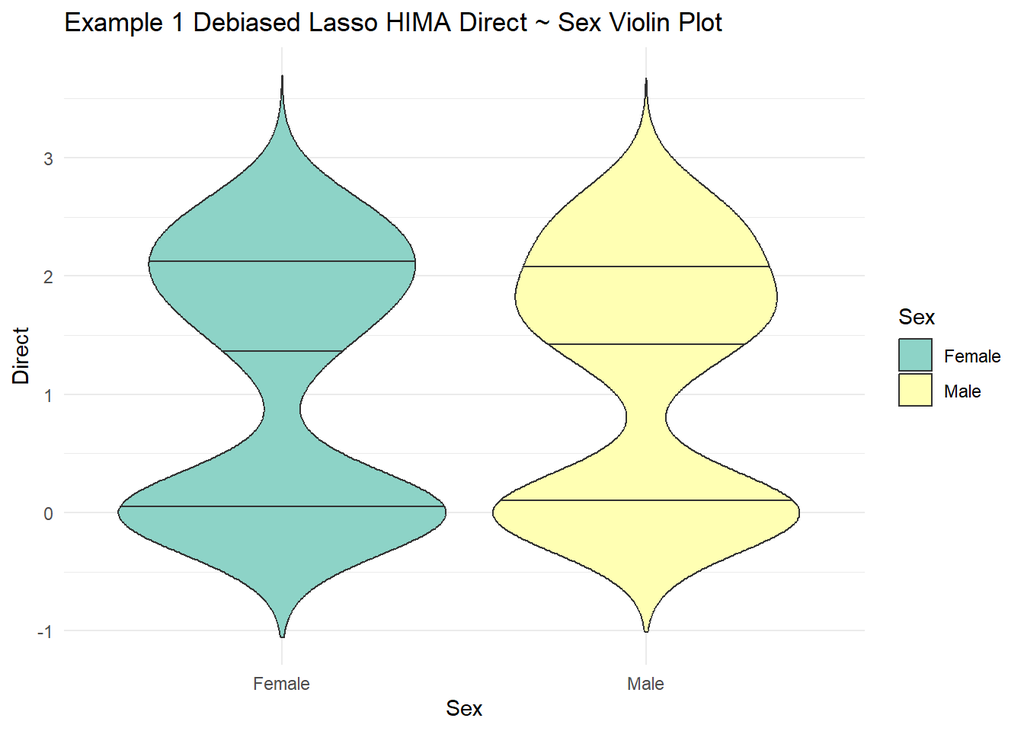

```r
E1dblasso$Sex <- ifelse(E1dblasso$Sex == 0, "Male", "Female")
E1dblasso_sex_pl <- plot_violins(E1dblasso, "Sex", "Direct", plotname = "Example 1 Debiased Lasso HIMA Direct ~ Sex Violin Plot")
E1dblasso_sex_pl
```

```r
boot_tests(E1dblasso, "Direct", "M3", mean)
```

```
## [1] "All values of t are equal to  0.291042601423512 \n Cannot calculate confidence intervals"
```

[output not shown]

##### Findings

The results of **dblassoHIMA** for Example 1 show:

The values for each effect are not normally distributed.

M2 has positive correlation with the direct effect. M3 has negative correlation with the direct effect.

All effects have a positive correlation with the outcome.

The direct effect and M2 have positive correlation with age.

The residuals cannot be attributed to the input data as a limiting factor.

### Mediation Analysis with Multiple Comparison Procedure HIMA

#### Mediator Identification

```r
e1 <- himaFit(Outcome ~ Treatment + Sex + Age,
              data.pheno = himaDat$Example1$PhenoData,
              data.M = himaDat$Example1$Mediator,
              mediator.type = "gaussian",
              penalty = "MCP", # Can be "DBlasso" for dblassoHIMA
              scale = FALSE
) # Disabled only for simulation data
```

```
## Running linear HIMA with MCP penalty...
```

```
## Step 1: Sure Independent Screening ...     (3:04:12 PM)
```

```
## Step 2: Penalized estimate (MCP) ...     (3:04:13 PM)
```

```
## Step 3: Joint significance test ...     (3:04:13 PM)
```

```
## Done!     (3:04:13 PM)
```

```r
e1
```

```
##   ID      alpha       beta alpha*beta Relative Importance (%)      p-value
## 1 M2  0.9137393  0.8461100  0.7731240                42.19850 1.093307e-08
## 2 M3 -0.7331281 -0.7424343  0.5442994                29.70884 6.210954e-05
## 3 M1  0.5771873  0.8917198  0.5146893                28.09267 1.614870e-03
```

```r
summary(Example1$Mediator[,e1[,"ID"]])
```

```
##        M2                  M3                M1
##  Min.   :-2.967920   Min.   :-4.1503   Min.   :-2.6848
##  1st Qu.:-0.003495   1st Qu.:-1.3377   1st Qu.:-0.1890
##  Median : 0.833371   Median :-0.2296   Median : 0.8665
##  Mean   : 0.899701   Mean   :-0.1922   Mean   : 0.9068
##  3rd Qu.: 1.680141   3rd Qu.: 0.8739   3rd Qu.: 1.9467
##  Max.   : 5.462254   Max.   : 4.9475   Max.   : 5.7642
```

```r
## End(Not run)
```

M1, M2, and M3 have been identified as the top three most significant mediator variables. (p < 0.05)

**alpha_hat** represents the effect the treatment has on the mediators.

**beta_hat** represents the effect the mediators have towards the outcome.

**alpha_se** is the standard error for **E(M | X, Cov).**

**beta_se** is the standard error for **E(Y | M, Cov).**

**IDE** stands for “Indirect Effect”, and is the result of **alpha_hat*beta_hat**.

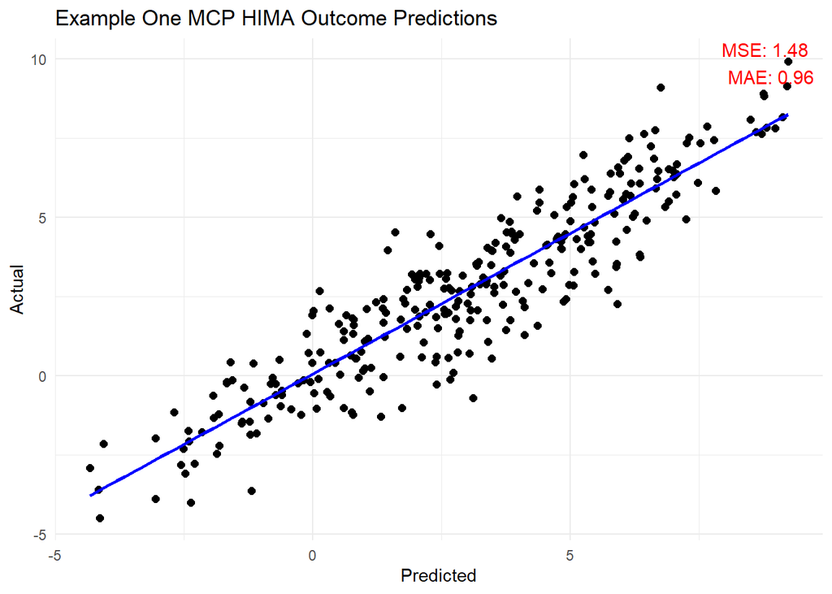

```r
E1mcp <- estimatedEffects(fit = e1, IDEcoefs = e1[,"alpha*beta"], betas = e1[,"beta"])
E1mcppl <- plot_mediator_adjustments(actual = himaDat$Example1$PhenoData$Outcome,
                                        estimations = E1mcp,
                                        mediator_indices = e1[,"ID"],
                                        plotname = "Example One MCP HIMA Outcome Predictions")
E1mcppl
```

The consideration of mediators allows the relationship between Treatment and Outcome to be much more accurately described.

The contribution towards the outcome by each mediator is calculated as **M * beta_hat.**

The contribution towards the outcome by the Direct Effect is calculated as the **E(Y | X, Cov) - IDE**.

The mediator adjusted prediction is **E(Y | X, M, Cov) = 𝛽*M + E(Y | X, Cov) - IDE**.

#### Effect Analysis

##### Test for Normality

*H<sub>0</sub>* : The values for every type of measured effect are drawn from the normal distribution.

*H<sub>1</sub>* : The values for every type of measured effect are drawn from outside the normal distribution.

```r
E1mcp_control_ks_results <- kstests(dat = E1mcp[E1mcp$Treatment == 0,], exclude = c("Treatment","Sex","Other", "DominantEffect", "Direct"))
```

```
## [1] "Outcome"   "Age"       "M2"        "M3"        "M1"        "Residuals"
## [7] "Adjusted"
```

```r
print(data.frame(E1mcp_control_ks_results))
```

```
##           D_Statistic       P_Value
## Outcome     0.3723868  1.009306e-15
## Age         1.0000000 9.777585e-111
## M2          0.1324823  2.316869e-02
## M3          0.1038529  1.291706e-01
## M1          0.2194817  9.707694e-06
## Residuals   0.1458297  9.018351e-03
## Adjusted    0.3054095  1.027533e-10
```

```r
E1mcp_experimental_ks_results <- kstests(dat = E1mcp[E1mcp$Treatment != 0,], exclude = c("Treatment","Sex","Other", "DominantEffect", "Direct"))
```

```
## [1] "Outcome"   "Age"       "M2"        "M3"        "M1"        "Residuals"
## [7] "Adjusted"
```

```r
print(data.frame(E1mcp_experimental_ks_results))
```

```
##           D_Statistic       P_Value
## Outcome     0.7812265  3.904117e-92
## Age         1.0000000 1.084275e-150
## M2          0.3920301  1.610761e-23
## M3          0.1761101  4.370890e-05
## M1          0.3824018  2.125567e-22
## Residuals   0.2722779  1.448861e-11
## Adjusted    0.8741880 2.931807e-115
```

##### Tests for Correlation

We reject *H<sub>0</sub>* (p < 0.05). In rejection of the null hypothesis, we shall test for test for whether there exists correlations between each mediator effect.

*H<sub>0</sub>* : There exists no correlation between a mediator effect and any other mediator effect.

*H<sub>1</sub>* : There exists a correlation between an effect and any other mediator effect.

```r
E1mcp_effect_cor <- perform_cor_tests(E1mcp, c(e1[,"ID"]), alternative = "two.sided", method = "spearman")
E1mcp_effect_cor
```

```
## $`M2 - M3`
##
##  Spearman's rank correlation rho
##
## data:  data[, x[i]] and data[, x[j]]
## S = 4291470, p-value = 0.4238
## alternative hypothesis: true rho is not equal to 0
## sample estimates:
##       rho
## 0.0463294
##
##
## $`M2 - M1`
##
##  Spearman's rank correlation rho
##
## data:  data[, x[i]] and data[, x[j]]
## S = 4302282, p-value = 0.4482
## alternative hypothesis: true rho is not equal to 0
## sample estimates:
##        rho
## 0.04392671
##
##
## $`M3 - M1`
##
##  Spearman's rank correlation rho
##
## data:  data[, x[i]] and data[, x[j]]
## S = 3935150, p-value = 0.0298
## alternative hypothesis: true rho is not equal to 0
## sample estimates:
##       rho
## 0.1255125
```

We cannot reject the null hypothesis(adjusted p > 0.05). We will follow up on this by testing for the correlation between each effect for the experimental group, where the direct effect is always present.

*H<sub>0</sub>* : There exists no correlation between an effect and any other effect in the experimental group.

*H<sub>1</sub>* : There exists a correlation between an effect and any other effect in the experimental group.

```r
E1mcp_effect_cor_e <- perform_cor_tests(E1mcp[E1mcp$Treatment != 0,], c(e1[,"ID"], "Direct"), alternative = "two.sided", method = "spearman")
E1mcp_effect_cor_e
```

```
## $`M2 - M3`
##
##  Spearman's rank correlation rho
##
## data:  data[, x[i]] and data[, x[j]]
## S = 916436, p-value = 0.4173
## alternative hypothesis: true rho is not equal to 0
## sample estimates:
##         rho
## -0.06201241
##
##
## $`M2 - M1`
##
##  Spearman's rank correlation rho
##
## data:  data[, x[i]] and data[, x[j]]
## S = 888636, p-value = 0.6969
## alternative hypothesis: true rho is not equal to 0
## sample estimates:
##         rho
## -0.02979637
##
##
## $`M2 - Direct`
##
##  Spearman's rank correlation rho
##
## data:  data[, x[i]] and data[, x[j]]
## S = 664418, p-value = 0.002329
## alternative hypothesis: true rho is not equal to 0
## sample estimates:
##       rho
## 0.2300385
##
##
## $`M3 - M1`
##
##  Spearman's rank correlation rho
##
```

[output cut: 15 more lines]

```
## sample estimates:
##        rho
## -0.2157013
##
##
## $`M1 - Direct`
##
##  Spearman's rank correlation rho
##
## data:  data[, x[i]] and data[, x[j]]
## S = 741518, p-value = 0.06485
## alternative hypothesis: true rho is not equal to 0
## sample estimates:
##       rho
## 0.1406912
```

We reject the null hypothesis: There exists positive correlation between M2 and the Direct Effect (adjusted p < 0.05). There exists negative correlation between M3 and the Direct Effect(adjusted p < 0.05). For the relationships between each mediator effect, the null hypothesis cannot be rejected. We will conduct bootstrap sampling to find the true mean of each effect in the control group and experimental group.

```r
E1mcp_control_long <- melt(E1mcp[E1mcp$Treatment == 0,e1[,"ID"]], variable.name = "Effect", value.name = "Contribution")
head(E1mcp_control_long)
```

```
##   Effect Contribution
## 1     M2   -0.3151984
## 2     M2   -2.0646497
## 3     M2   -0.1466336
## 4     M2    0.8592601
## 5     M2    1.1211563
## 6     M2    0.1370233
```

```r
E1mcp_control_pl <- plot_violins(E1mcp_control_long, x = "Effect", y = "Contribution", "Example 1 MCP HIMA Control Group Effects")
E1mcp_control_boot <- boot_tests(data = E1mcp_control_long, x = "Effect", y = "Contribution", statistic = mean)
E1mcp_control_boot
```

```
##          2.5%      97.5%
## M2  0.1264749 0.48186134
## M3 -0.3842468 0.02767778
## M1  0.2452947 0.77443454
```

```r
E1mcp_experimental_long <- melt(E1mcp[E1mcp$Treatment != 0,c(e1[,"ID"], "Direct")], variable.name = "Effect", value.name = "Contribution")
head(E1mcp_experimental_long)
```

```
##   Effect Contribution
## 1     M2     1.866732
## 2     M2     1.416971
## 3     M2     1.653018
## 4     M2     4.621668
## 5     M2    -0.176141
## 6     M2    -0.194830
```

```r
E1mcp_experimental_pl <- plot_violins(E1mcp_experimental_long, x = "Effect", y = "Contribution", "Example 1 MCP HIMA Experimental Group Effects")
E1mcp_experimental_boot <- boot_tests(data = E1mcp_experimental_long, x = "Effect", y = "Contribution", statistic = mean)
E1mcp_experimental_boot
```

```
##             2.5%     97.5%
## M2     0.9172177 1.2746997
## M3     0.1951140 0.5494207
## M1     0.8408070 1.2440668
## Direct 2.0142813 2.1239260
```

In the experimental group, the mean contributions of each effect are much higher than they are in the control group.

We are going to test for correlations between effects and the measured outcome and residuals of the mediator adjusted prediction to the measured outcome.

*H<sub>0</sub>* : There exists no correlation between any effect and measured outcome in the experimental group.

*H<sub>1</sub>* : There exists a correlation between any effect and measured outcome in the experimental group.

```r
E1mcp_effect_outcome_cor <- perform_cor_tests(E1mcp, x = c(e1[,"ID"], "Direct", "Residuals"), y = "Outcome", alternative = "two.sided", method = "spearman")
E1mcp_effect_outcome_cor
```

```
## $`M2 - Outcome`
##
##  Spearman's rank correlation rho
##
## data:  data[, name] and data[, y]
## S = 2191026, p-value < 2.2e-16
## alternative hypothesis: true rho is not equal to 0
## sample estimates:
##       rho
## 0.5130999
##
##
## $`M3 - Outcome`
##
##  Spearman's rank correlation rho
##
## data:  data[, name] and data[, y]
## S = 2170348, p-value < 2.2e-16
## alternative hypothesis: true rho is not equal to 0
## sample estimates:
##       rho
## 0.5176951
##
##
## $`M1 - Outcome`
##
##  Spearman's rank correlation rho
##
## data:  data[, name] and data[, y]
## S = 1799762, p-value < 2.2e-16
## alternative hypothesis: true rho is not equal to 0
## sample estimates:
##       rho
## 0.6000484
##
##
## $`Direct - Outcome`
##
##  Spearman's rank correlation rho
##
## data:  data[, name] and data[, y]
## S = 2198449, p-value < 2.2e-16
## alternative hypothesis: true rho is not equal to 0
## sample estimates:
##       rho
## 0.5114504
##
##
## $`Residuals - Outcome`
##
##  Spearman's rank correlation rho
##
## data:  data[, name] and data[, y]
## S = 4005596, p-value = 0.05739
## alternative hypothesis: true rho is not equal to 0
## sample estimates:
##       rho
## 0.1098577
```

We can reject the null hypothesis(p < 0.05). For all effects, there exists positive correlation to the outcome. The residuals of the model do not show strong correlation with the Outcome, indicating that it is unlikely for magnitude of outcome to be a limiting factor in the accuracy of effect contributions. We will move on to testing the correlation the effects and residuals have to the Age of the subjects.

*H<sub>0</sub>* : There exists no correlation between any effect and age in the experimental group.

*H<sub>1</sub>* : There exists a correlation between any effect and age in the experimental group.

```r
E1mcp_effect_age_cor <- perform_cor_tests(E1mcp, x = c(e1[,"ID"], "Direct", "Residuals"), y = "Age", alternative = "two.sided", method = "spearman")
E1mcp_effect_age_cor
```

```
## $`M2 - Age`
##
##  Spearman's rank correlation rho
##
## data:  data[, name] and data[, y]
## S = 3669834, p-value = 0.00133
## alternative hypothesis: true rho is not equal to 0
## sample estimates:
##       rho
## 0.1844723
##
##
## $`M3 - Age`
##
##  Spearman's rank correlation rho
##
## data:  data[, name] and data[, y]
## S = 5112951, p-value = 0.01824
## alternative hypothesis: true rho is not equal to 0
## sample estimates:
##       rho
## -0.136224
##
##
## $`M1 - Age`
##
##  Spearman's rank correlation rho
##
## data:  data[, name] and data[, y]
## S = 3899019, p-value = 0.02068
## alternative hypothesis: true rho is not equal to 0
## sample estimates:
##       rho
## 0.1335417
##
##
## $`Direct - Age`
##
##  Spearman's rank correlation rho
##
## data:  data[, name] and data[, y]
## S = 2763221, p-value = 4.297e-12
## alternative hypothesis: true rho is not equal to 0
## sample estimates:
##       rho
## 0.3859442
##
##
## $`Residuals - Age`
##
##  Spearman's rank correlation rho
##
## data:  data[, name] and data[, y]
## S = 4640491, p-value = 0.59
## alternative hypothesis: true rho is not equal to 0
## sample estimates:
##        rho
## -0.0312317
```

We can reject the null hypothesis(p < 0.05). M2, and the direct effect have positive correlation with age. These results suggest that age of the subject affects their sensitivity to the effects of each mediator. The correlation between Age and the residuals of the mediator adjusted model do not have statistical significance, suggesting that the age of the subject does not strongly influence the model’s inaccuracies.

##### Test for differences across groups

We are going to use the Kruskal-Wallis test to determine the difference in variance for effects, residuals, and the outcome across sexes.

*H<sub>0</sub>* : There exists no difference in medians in any effects and the outcome across male and female subjects.

*H<sub>1</sub>* : There exists a difference in medians in any effects and the outcome across male and female subjects.

```r
E1mcp_kruskal_sex <- perform_kruskal(E1mcp, "Sex", c(e1[,"ID"], "Direct", "Outcome", "Residuals"))
```

```
## [1] "M2"
## [1] "M3"
## [1] "M1"
## [1] "Direct"
## [1] "Outcome"
## [1] "Residuals"
```

```r
E1mcp_kruskal_sex
```

```
## $M2
##
##  Kruskal-Wallis rank sum test
##
## data:  y_val by x_val
## Kruskal-Wallis chi-squared = 0.19416, df = 1, p-value = 0.6595
##
##
## $M3
##
##  Kruskal-Wallis rank sum test
##
## data:  y_val by x_val
## Kruskal-Wallis chi-squared = 4.0034, df = 1, p-value = 0.04541
##
##
## $M1
##
##  Kruskal-Wallis rank sum test
##
## data:  y_val by x_val
## Kruskal-Wallis chi-squared = 0.21958, df = 1, p-value = 0.6394
##
##
## $Direct
##
##  Kruskal-Wallis rank sum test
##
## data:  y_val by x_val
## Kruskal-Wallis chi-squared = 0.0030685, df = 1, p-value = 0.9558
##
##
## $Outcome
##
##  Kruskal-Wallis rank sum test
##
## data:  y_val by x_val
## Kruskal-Wallis chi-squared = 0.048834, df = 1, p-value = 0.8251
##
##
## $Residuals
##
##  Kruskal-Wallis rank sum test
##
## data:  y_val by x_val
## Kruskal-Wallis chi-squared = 0.77431, df = 1, p-value = 0.3789
```

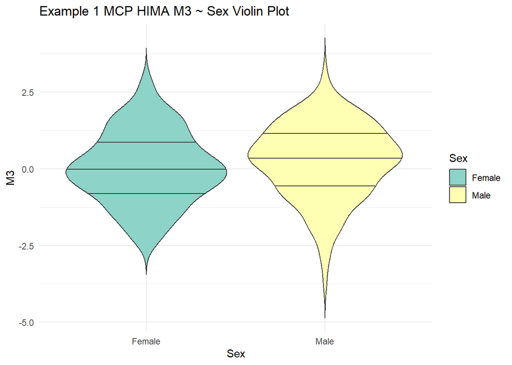

```r
E1mcp$Sex <- ifelse(E1mcp$Sex == 0, "Male", "Female")
E1mcp_sex_pl <- plot_violins(E1mcp, "Sex", "M3", plotname = "Example 1 MCP HIMA M3 ~ Sex Violin Plot")
E1mcp_sex_pl
```

```r
boot_tests(E1mcp, "Sex", "M3", mean)
```

```
##               2.5%     97.5%
## Male    0.04595862 0.4358270
## Female -0.15921421 0.2094037
```

##### Findings

The results of **MCP HIMA** for Example 1 show:

M2 has positive correlation with the direct effect. M3 has negative correlation with the direct effect.

All effects have a positive correlation with the outcome.

The direct effect and M2 have positive correlation with age.

The residuals cannot be attributed to the input data as a limiting factor.

### Mediation Analysis with eHIMA

#### Mediator Identification

```r
head(himaDat$Example1$PhenoData)
```

```
##   Treatment   Outcome Sex Age
## 1         1 2.7653005   0  54
## 2         1 0.5754423   1  38
## 3         1 1.7632589   0  29
## 4         1 9.9327242   0  34
## 5         1 1.8183044   0  29
## 6         1 0.1024832   0  55
```

```r
eHIMA.fit <- eHIMA(
  X = himaDat$Example1$PhenoData$Treatment,
  Y = himaDat$Example1$PhenoData$Outcome,
  M = himaDat$Example1$Mediator,
  COV = himaDat$Example1$PhenoData[, c("Sex", "Age")],
  scale = FALSE, # Disabled only for simulation data
  FDRcut = 0.05,
  verbose = TRUE
)
```

```
## Step 1: Sure Independent Screening + minimax concave penalty (MCP) ...     (3:04:14 PM)
```

```
##         Top 106 mediators are selected: M1, M2, M3, M6, M7, M12, M13, M14, M16, M17, M21, M22, M29, M30, M31, M32, M34, M37, M40, M41, M48, M49, M50, M58, M60, M61, M62, M66, M68, M74, M76, M78, M82, M83, M84, M86, M87, M89, M91, M96, M97, M98, M103, M105, M109, M116, M117, M119, M120, M122, M125…
```

```
##         Adjusting for covariate(s): Sex, Age
```

```
## Step 2: Refitted partial regression ...     (3:04:14 PM)
```

```
## Step 3: Divide-aggregate composite-null test (DACT) ...     (3:04:14 PM)
```

```
##         3 significant mediator(s) identified.
```

```
## Done!     (3:04:14 PM)
```

```r
eHIMA.fit
```

```
##   Index  alpha_hat  alpha_se   beta_hat    beta_se       IDE     rimp
## 1    M2  0.9137393 0.1553407  0.8461100 0.04763681 0.7731240 42.19850
## 2    M3 -0.7331281 0.1804393 -0.7424343 0.04116195 0.5442994 29.70884
## 3    M1  0.5771873 0.1813573  0.8917198 0.04101848 0.5146893 28.09267
##           pmax
## 1 5.985580e-11
## 2 1.008716e-06
## 3 3.602839e-05
```

```r
summary(Example1$Mediator[,eHIMA.fit[,"Index"]])
```

```
##        M2                  M3                M1
##  Min.   :-2.967920   Min.   :-4.1503   Min.   :-2.6848
##  1st Qu.:-0.003495   1st Qu.:-1.3377   1st Qu.:-0.1890
##  Median : 0.833371   Median :-0.2296   Median : 0.8665
##  Mean   : 0.899701   Mean   :-0.1922   Mean   : 0.9068
##  3rd Qu.: 1.680141   3rd Qu.: 0.8739   3rd Qu.: 1.9467
##  Max.   : 5.462254   Max.   : 4.9475   Max.   : 5.7642
```

```r
## End(Not run)
```

M1, M2, and M3 have been identified as the top three most significant mediator variables. (p < 0.05)

**alpha_hat** represents the effect the treatment has on the mediators.

**beta_hat** represents the effect the mediators have towards the outcome.

**alpha_se** is the standard error for **E(M | X, Cov).**

**beta_se** is the standard error for **E(Y | M, Cov).**

**IDE** stands for “Indirect Effect”, and is the result of **alpha_hat*beta_hat**.

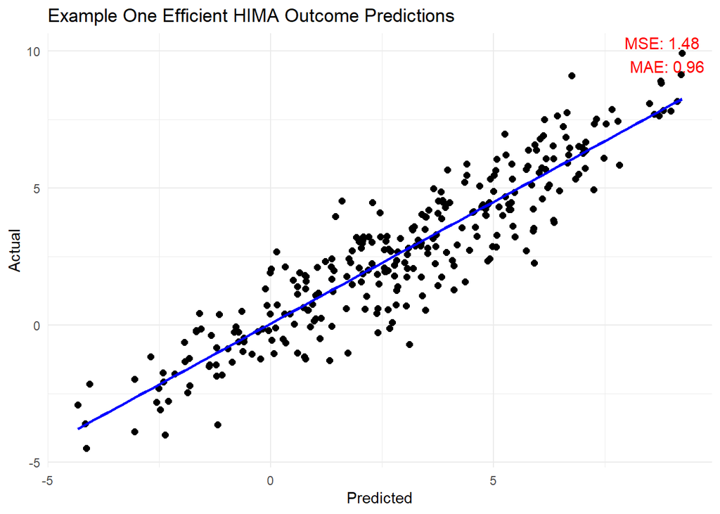

```r
E1efficient <- estimatedEffects(fit = eHIMA.fit)
E1efficientpl <- plot_mediator_adjustments(actual = himaDat$Example1$PhenoData$Outcome,
                             estimations = E1efficient,
                             mediator_indices = eHIMA.fit[,"Index"],
                             plotname = "Example One Efficient HIMA Outcome Predictions")
E1efficientpl
```

The consideration of mediators allows the relationship between Treatment and Outcome to be much more accurately described.

The contribution towards the outcome by each mediator is calculated as **M * beta_hat.**

The contribution towards the outcome by the Direct Effect is calculated as the **E(Y | X, Cov) - IDE**.

The mediator adjusted prediction is **E(Y | X, M, Cov) = 𝛽*M + E(Y | X, Cov) - IDE**.

#### Effect Analysis

##### Test for Normality

*H<sub>0</sub>* : The values for every type of measured effect are drawn from the normal distribution.

*H<sub>1</sub>* : The values for every type of measured effect are drawn from outside the normal distribution.

```r
E1efficient_control_ks_results <- kstests(dat = E1efficient[E1efficient$Treatment == 0,], exclude = c("Treatment","Sex","Other", "DominantEffect", "Direct"))
```

```
## [1] "Outcome"   "Age"       "M2"        "M3"        "M1"        "Residuals"
## [7] "Adjusted"
```

```r
print(data.frame(E1efficient_control_ks_results))
```

```
##           D_Statistic       P_Value
## Outcome     0.3723868  1.009306e-15
## Age         1.0000000 9.777585e-111
## M2          0.1324823  2.316869e-02
## M3          0.1038529  1.291706e-01
## M1          0.2194817  9.707694e-06
## Residuals   0.1458297  9.018351e-03
## Adjusted    0.3054095  1.027533e-10
```

```r
E1efficient_experimental_ks_results <- kstests(dat = E1efficient[E1efficient$Treatment != 0,], exclude = c("Treatment","Sex","Other", "DominantEffect", "Direct"))
```

```
## [1] "Outcome"   "Age"       "M2"        "M3"        "M1"        "Residuals"
## [7] "Adjusted"
```

```r
print(data.frame(E1efficient_experimental_ks_results))
```

```
##           D_Statistic       P_Value
## Outcome     0.7812265  3.904117e-92
## Age         1.0000000 1.084275e-150
## M2          0.3920301  1.610762e-23
## M3          0.1761101  4.370890e-05
## M1          0.3824018  2.125567e-22
## Residuals   0.2722779  1.448862e-11
## Adjusted    0.8741880 2.931805e-115
```

##### Tests for Correlation

We reject *H<sub>0</sub>* (p < 0.05). In rejection of the null hypothesis, we shall test for test for whether there exists correlations between each mediator effect.

*H<sub>0</sub>* : There exists no correlation between a mediator effect and any other mediator effect.

*H<sub>1</sub>* : There exists a correlation between an effect and any other mediator effect.

```r
E1efficient_effect_cor <- perform_cor_tests(E1efficient, c(eHIMA.fit[,"Index"]), alternative = "two.sided", method = "spearman")
E1efficient_effect_cor
```

```
## $`M2 - M3`
##
##  Spearman's rank correlation rho
##
## data:  data[, x[i]] and data[, x[j]]
## S = 4291470, p-value = 0.4238
## alternative hypothesis: true rho is not equal to 0
## sample estimates:
##       rho
## 0.0463294
##
##
## $`M2 - M1`
##
##  Spearman's rank correlation rho
##
## data:  data[, x[i]] and data[, x[j]]
## S = 4302282, p-value = 0.4482
## alternative hypothesis: true rho is not equal to 0
## sample estimates:
##        rho
## 0.04392671
##
##
## $`M3 - M1`
##
##  Spearman's rank correlation rho
##
## data:  data[, x[i]] and data[, x[j]]
## S = 3935150, p-value = 0.0298
## alternative hypothesis: true rho is not equal to 0
## sample estimates:
##       rho
## 0.1255125
```

We cannot reject the null hypothesis(adjusted p > 0.05). We will follow up on this by testing for the correlation between each effect for the experimental group, where the direct effect is always present.

*H<sub>0</sub>* : There exists no correlation between an effect and any other effect in the experimental group.

*H<sub>1</sub>* : There exists a correlation between an effect and any other effect in the experimental group.

```r
E1efficient_effect_cor_e <- perform_cor_tests(E1efficient[E1efficient$Treatment > 0,], c(eHIMA.fit[,"Index"], "Direct"), alternative = "two.sided", method = "spearman")
E1efficient_effect_cor_e
```

```
## $`M2 - M3`
##
##  Spearman's rank correlation rho
##
## data:  data[, x[i]] and data[, x[j]]
## S = 916436, p-value = 0.4173
## alternative hypothesis: true rho is not equal to 0
## sample estimates:
##         rho
## -0.06201241
##
##
## $`M2 - M1`
##
##  Spearman's rank correlation rho
##
## data:  data[, x[i]] and data[, x[j]]
## S = 888636, p-value = 0.6969
## alternative hypothesis: true rho is not equal to 0
## sample estimates:
##         rho
## -0.02979637
##
##
## $`M2 - Direct`
##
##  Spearman's rank correlation rho
##
## data:  data[, x[i]] and data[, x[j]]
## S = 664418, p-value = 0.002329
## alternative hypothesis: true rho is not equal to 0
## sample estimates:
##       rho
## 0.2300385
##
##
## $`M3 - M1`
##
##  Spearman's rank correlation rho
##
```

[output cut: 15 more lines]

```
## sample estimates:
##        rho
## -0.2157013
##
##
## $`M1 - Direct`
##
##  Spearman's rank correlation rho
##
## data:  data[, x[i]] and data[, x[j]]
## S = 741518, p-value = 0.06485
## alternative hypothesis: true rho is not equal to 0
## sample estimates:
##       rho
## 0.1406912
```

We reject the null hypothesis: There exists positive correlation between M2 and the Direct Effect (p < 0.05). There exists negative correlation between M3 and the Direct Effect. For the relationships between each mediator effect, the null hypothesis cannot be rejected. We will conduct bootstrap sampling to find the true mean of each effect in the control group and experimental group.

```r
E1efficient_control_long <- melt(E1efficient[E1efficient$Treatment == 0,eHIMA.fit[,"Index"]], variable.name = "Effect", value.name = "Contribution")
head(E1efficient_control_long)
```

```
##   Effect Contribution
## 1     M2   -0.3151984
## 2     M2   -2.0646497
## 3     M2   -0.1466336
## 4     M2    0.8592601
## 5     M2    1.1211563
## 6     M2    0.1370232
```

```r
E1efficient_control_pl <- plot_violins(E1efficient_control_long, x = "Effect", y = "Contribution", "Example 1 Efficient HIMA Control Group Effects")
E1efficient_control_boot <- boot_tests(data = E1efficient_control_long, x = "Effect", y = "Contribution", statistic = mean)
E1efficient_control_boot
```

```
##          2.5%      97.5%
## M2  0.1306648 0.48478166
## M3 -0.3766389 0.04003311
## M1  0.2535205 0.76458938
```

```r
E1efficient_experimental_long <- melt(E1efficient[E1efficient$Treatment != 0,c(eHIMA.fit[,"Index"], "Direct")], variable.name = "Effect", value.name = "Contribution")
head(E1efficient_experimental_long)
```

```
##   Effect Contribution
## 1     M2     1.866732
## 2     M2     1.416971
## 3     M2     1.653018
## 4     M2     4.621668
## 5     M2    -0.176141
## 6     M2    -0.194830
```

```r
E1efficient_experimental_pl <- plot_violins(E1efficient_experimental_long, x = "Effect", y = "Contribution", "Example 1 Efficient HIMA Experimental Group Effects")
E1efficient_experimental_boot <- boot_tests(data = E1efficient_experimental_long, x = "Effect", y = "Contribution", statistic = mean)
E1efficient_experimental_boot
```

```
##             2.5%     97.5%
## M2     0.9216622 1.2630011
## M3     0.2033543 0.5386725
## M1     0.8479364 1.2199189
## Direct 2.0082669 2.1291201
```

In the experimental group, the mean contributions of each effect are much higher than they are in the control group.

We are going to test for correlations between effects and the measured outcome and residuals of the mediator adjusted prediction to the measured outcome.

*H<sub>0</sub>* : There exists no correlation between any effect and measured outcome in the experimental group.

*H<sub>1</sub>* : There exists a correlation between any effect and measured outcome in the experimental group.

```r
E1efficient_effect_outcome_cor <- perform_cor_tests(E1efficient, x = c(eHIMA.fit[,"Index"], "Direct", "Residuals"), y = "Outcome", alternative = "two.sided", method = "spearman")
E1efficient_effect_outcome_cor
```

```
## $`M2 - Outcome`
##
##  Spearman's rank correlation rho
##
## data:  data[, name] and data[, y]
## S = 2191026, p-value < 2.2e-16
## alternative hypothesis: true rho is not equal to 0
## sample estimates:
##       rho
## 0.5130999
##
##
## $`M3 - Outcome`
##
##  Spearman's rank correlation rho
##
## data:  data[, name] and data[, y]
## S = 2170348, p-value < 2.2e-16
## alternative hypothesis: true rho is not equal to 0
## sample estimates:
##       rho
## 0.5176951
##
##
## $`M1 - Outcome`
##
##  Spearman's rank correlation rho
##
## data:  data[, name] and data[, y]
## S = 1799762, p-value < 2.2e-16
## alternative hypothesis: true rho is not equal to 0
## sample estimates:
##       rho
## 0.6000484
##
##
## $`Direct - Outcome`
##
##  Spearman's rank correlation rho
##
## data:  data[, name] and data[, y]
## S = 2198449, p-value < 2.2e-16
## alternative hypothesis: true rho is not equal to 0
## sample estimates:
##       rho
## 0.5114504
##
##
## $`Residuals - Outcome`
##
##  Spearman's rank correlation rho
##
## data:  data[, name] and data[, y]
## S = 4005596, p-value = 0.05739
## alternative hypothesis: true rho is not equal to 0
## sample estimates:
##       rho
## 0.1098577
```

We can reject the null hypothesis(p < 0.05). For all effects, there exists positive correlation to the outcome. The residuals of the model do not show strong correlation with the Outcome, indicating that it is unlikely for magnitude of outcome to be a limiting factor in the accuracy of effect contributions. We will move on to testing the correlation the effects and residuals have to the Age of the subjects.

*H<sub>0</sub>* : There exists no correlation between any effect and age in the experimental group.

*H<sub>1</sub>* : There exists a correlation between any effect and age in the experimental group.

```r
E1efficient_effect_age_cor <- perform_cor_tests(E1efficient, x = c(eHIMA.fit[,"Index"], "Direct", "Residuals"), y = "Age", alternative = "two.sided", method = "spearman")
E1efficient_effect_age_cor
```

```
## $`M2 - Age`
##
##  Spearman's rank correlation rho
##
## data:  data[, name] and data[, y]
## S = 3669834, p-value = 0.00133
## alternative hypothesis: true rho is not equal to 0
## sample estimates:
##       rho
## 0.1844723
##
##
## $`M3 - Age`
##
##  Spearman's rank correlation rho
##
## data:  data[, name] and data[, y]
## S = 5112951, p-value = 0.01824
## alternative hypothesis: true rho is not equal to 0
## sample estimates:
##       rho
## -0.136224
##
##
## $`M1 - Age`
##
##  Spearman's rank correlation rho
##
## data:  data[, name] and data[, y]
## S = 3899019, p-value = 0.02068
## alternative hypothesis: true rho is not equal to 0
## sample estimates:
##       rho
## 0.1335417
##
##
## $`Direct - Age`
##
##  Spearman's rank correlation rho
##
## data:  data[, name] and data[, y]
## S = 2763221, p-value = 4.297e-12
## alternative hypothesis: true rho is not equal to 0
## sample estimates:
##       rho
## 0.3859442
##
##
## $`Residuals - Age`
##
##  Spearman's rank correlation rho
##
## data:  data[, name] and data[, y]
## S = 4640491, p-value = 0.59
## alternative hypothesis: true rho is not equal to 0
## sample estimates:
##        rho
## -0.0312317
```

We can reject the null hypothesis(adjusted p < 0.05). M2, and the direct effect have positive correlation with the age. These results suggest that age of the subject affects their sensitivity to the effects of each mediator. The correlation between Age and the residuals of the mediator adjusted model do not have statistical significance, suggesting that the age of the subject does not strongly influence the model’s inaccuracies.

##### Test for differences across groups

We are going to use the Kruskal-Wallis test to determine the difference in variance for effects, residuals, and the outcome across sexes.

*H<sub>0</sub>* : There exists no difference in medians in any effects and the outcome across male and female subjects.

*H<sub>1</sub>* : There exists a difference in medians in any effects and the outcome across male and female subjects.

```r
E1efficient_kruskal_sex <- perform_kruskal(E1efficient, "Sex", c(e1[,"ID"], "Direct", "Outcome", "Residuals"))
```

```
## [1] "M2"
## [1] "M3"
## [1] "M1"
## [1] "Direct"
## [1] "Outcome"
## [1] "Residuals"
```

```r
E1efficient_kruskal_sex
```

```
## $M2
##
##  Kruskal-Wallis rank sum test
##
## data:  y_val by x_val
## Kruskal-Wallis chi-squared = 0.19416, df = 1, p-value = 0.6595
##
##
## $M3
##
##  Kruskal-Wallis rank sum test
##
## data:  y_val by x_val
## Kruskal-Wallis chi-squared = 4.0034, df = 1, p-value = 0.04541
##
##
## $M1
##
##  Kruskal-Wallis rank sum test
##
## data:  y_val by x_val
## Kruskal-Wallis chi-squared = 0.21958, df = 1, p-value = 0.6394
##
##
## $Direct
##
##  Kruskal-Wallis rank sum test
##
## data:  y_val by x_val
## Kruskal-Wallis chi-squared = 0.0030685, df = 1, p-value = 0.9558
##
##
## $Outcome
##
##  Kruskal-Wallis rank sum test
##
## data:  y_val by x_val
## Kruskal-Wallis chi-squared = 0.048834, df = 1, p-value = 0.8251
##
##
## $Residuals
##
##  Kruskal-Wallis rank sum test
##
## data:  y_val by x_val
## Kruskal-Wallis chi-squared = 0.77431, df = 1, p-value = 0.3789
```

The null hypothesis cannot be rejected(adjusted p > 0.05). The difference in medians in residuals in male subjects and female subjects is statistically insignificant, suggesting that the sex of the patient is not a limiting factor in the accuracy of the model.

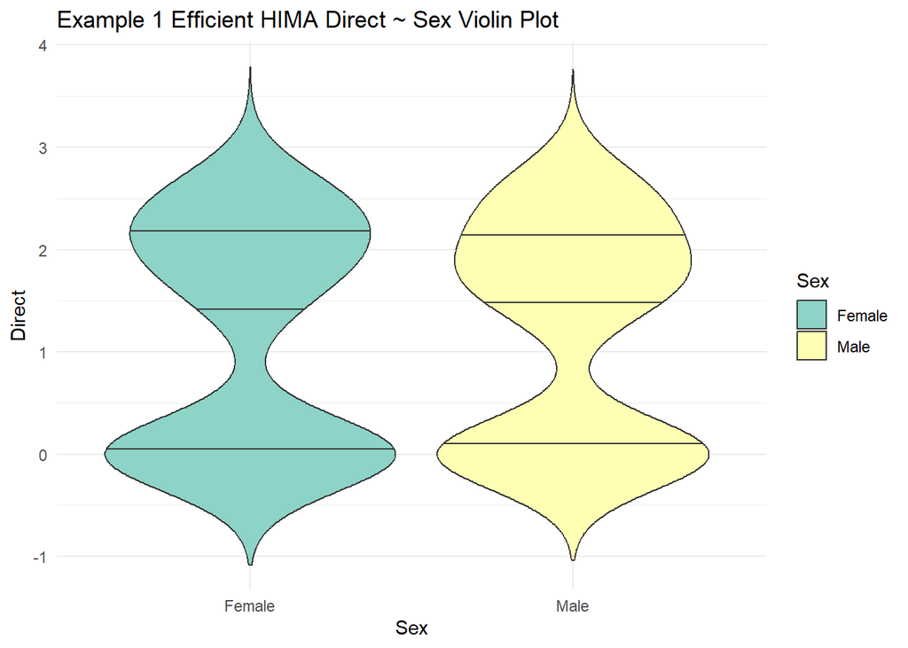

```r
E1efficient$Sex <- ifelse(E1efficient$Sex == 0, "Male", "Female")
E1efficient_sex_pl <- plot_violins(E1efficient, "Sex", "Direct", plotname = "Example 1 Efficient HIMA Direct ~ Sex Violin Plot")
E1efficient_sex_pl
```

```r
boot_tests(E1efficient, "Sex", "Direct", mean)
```

```
##             2.5%    97.5%
## Male   1.0526701 1.387288
## Female 0.9901221 1.337007
```

##### Findings

The results of **eHIMA** for Example 1 show:

M2 has positive correlation with the direct effect. M3 has negative correlation with the direct effect.

All effects have a positive correlation with the outcome.

The direct effect and M2 have positive correlation with age.

The residuals cannot be attributed to the input data as a limiting factor.

### Mediation Analysis with MCP eHIMA

#### Mediator Identification

```r
e1e <- himaFit(Outcome ~ Treatment + Sex + Age,
               data.pheno = himaDat$Example1$PhenoData,
               data.M = himaDat$Example1$Mediator,
               mediator.type = "gaussian",
               efficient = TRUE,
               penalty = "MCP", # Efficient HIMA does not support DBlasso
               scale = FALSE
) # Disabled only for simulation data
```

```
## Running efficient HIMA with MCP penalty...
```

```
## Step 1: Sure Independent Screening + minimax concave penalty (MCP) ...     (3:04:15 PM)
```

```
## Step 2: Refitted partial regression ...     (3:04:15 PM)
```

```
## Step 3: Divide-aggregate composite-null test (DACT) ...     (3:04:15 PM)
```

```
## Done!     (3:04:15 PM)
```

```r
e1e
```

```
##   ID      alpha       beta alpha*beta Relative Importance (%)      p-value
## 1 M2  0.9137393  0.8461100  0.7731240                42.19850 5.985580e-11
## 2 M3 -0.7331281 -0.7424343  0.5442994                29.70884 1.008716e-06
## 3 M1  0.5771873  0.8917198  0.5146893                28.09267 3.602839e-05
```

```r
summary(Example1$Mediator[,e1e[,"ID"]])
```

```
##        M2                  M3                M1
##  Min.   :-2.967920   Min.   :-4.1503   Min.   :-2.6848
##  1st Qu.:-0.003495   1st Qu.:-1.3377   1st Qu.:-0.1890
##  Median : 0.833371   Median :-0.2296   Median : 0.8665
##  Mean   : 0.899701   Mean   :-0.1922   Mean   : 0.9068
##  3rd Qu.: 1.680141   3rd Qu.: 0.8739   3rd Qu.: 1.9467
##  Max.   : 5.462254   Max.   : 4.9475   Max.   : 5.7642
```

```r
## End(Not run)
```

M1, M2, and M3 have been identified as the top three most significant mediator variables. (p < 0.05)

**alpha_hat** represents the effect the treatment has on the mediators.

**beta_hat** represents the effect the mediators have towards the outcome.

**alpha_se** is the standard error for **E(M | X, Cov).**

**beta_se** is the standard error for **E(Y | M, Cov).**

**IDE** stands for “Indirect Effect”, and is the result of **alpha_hat*beta_hat**.

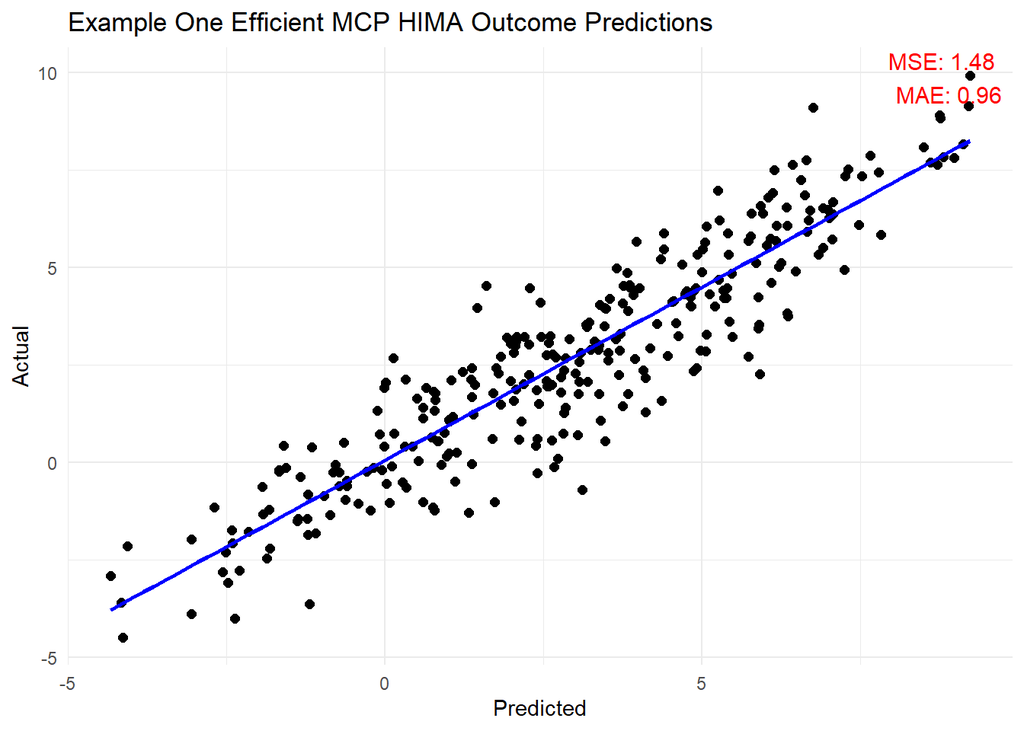

```r
E1mcpEfficient<- estimatedEffects(fit = e1e, IDEcoefs = e1e[,"alpha*beta"], betas = e1e[,"beta"])
E1mcpefficientpl <- plot_mediator_adjustments(actual = himaDat$Example1$PhenoData$Outcome,
                         estimations = E1mcpEfficient,
                         mediator_indices = e1e[,"ID"],
                         plotname = "Example One Efficient MCP HIMA Outcome Predictions")
E1mcpefficientpl
```

The consideration of mediators allows the relationship between Treatment and Outcome to be much more accurately described.

The contribution towards the outcome by each mediator is calculated as **M * beta_hat.**

The contribution towards the outcome by the Direct Effect is calculated as the **E(Y | X, Cov) - IDE**.

The mediator adjusted prediction is **E(Y | X, M, Cov) = 𝛽*M + E(Y | X, Cov) - IDE**.

#### Effect Analysis

##### Test for Normality

*H<sub>0</sub>* : The values for every type of measured effect are drawn from the normal distribution.

*H<sub>1</sub>* : The values for every type of measured effect are drawn from outside the normal distribution.

```r
E1mcpEfficient_control_ks_results <- kstests(dat = E1mcpEfficient[E1mcpEfficient$Treatment == 0,], exclude = c("Treatment","Sex","Other", "DominantEffect", "Direct"))
```

```
## [1] "Outcome"   "Age"       "M2"        "M3"        "M1"        "Residuals"
## [7] "Adjusted"
```

```r
print(data.frame(E1mcpEfficient_control_ks_results))
```

```
##           D_Statistic       P_Value
## Outcome     0.3723868  1.009306e-15
## Age         1.0000000 9.777585e-111
## M2          0.1324823  2.316869e-02
## M3          0.1038529  1.291706e-01
## M1          0.2194817  9.707694e-06
## Residuals   0.1458297  9.018351e-03
## Adjusted    0.3054095  1.027533e-10
```

```r
E1mcpEfficient_experimental_ks_results <- kstests(dat = E1mcpEfficient[E1mcpEfficient$Treatment != 0,], exclude = c("Treatment","Sex","Other", "DominantEffect", "Direct"))
```

```
## [1] "Outcome"   "Age"       "M2"        "M3"        "M1"        "Residuals"
## [7] "Adjusted"
```

```r
print(data.frame(E1mcpEfficient_experimental_ks_results))
```

```
##           D_Statistic       P_Value
## Outcome     0.7812265  3.904117e-92
## Age         1.0000000 1.084275e-150
## M2          0.3920301  1.610762e-23
## M3          0.1761101  4.370890e-05
## M1          0.3824018  2.125567e-22
## Residuals   0.2722779  1.448862e-11
## Adjusted    0.8741880 2.931805e-115
```

##### Tests for Correlation

We reject *H<sub>0</sub>* (p < 0.05). In rejection of the null hypothesis, we shall test for whether there exists correlations between each mediator effect.

*H<sub>0</sub>* : There exists no correlation between a mediator effect and any other mediator effect.

*H<sub>1</sub>* : There exists a correlation between an effect and any other mediator effect.

```r
E1mcpEfficient_effect_cor <- perform_cor_tests(E1mcpEfficient, c(e1e[,"ID"]), alternative = "two.sided", method = "spearman")
E1mcpEfficient_effect_cor
```

```
## $`M2 - M3`
##
##  Spearman's rank correlation rho
##
## data:  data[, x[i]] and data[, x[j]]
## S = 4291470, p-value = 0.4238
## alternative hypothesis: true rho is not equal to 0
## sample estimates:
##       rho
## 0.0463294
##
##
## $`M2 - M1`
##
##  Spearman's rank correlation rho
##
## data:  data[, x[i]] and data[, x[j]]
## S = 4302282, p-value = 0.4482
## alternative hypothesis: true rho is not equal to 0
## sample estimates:
##        rho
## 0.04392671
##
##
## $`M3 - M1`
##
##  Spearman's rank correlation rho
##
## data:  data[, x[i]] and data[, x[j]]
## S = 3935150, p-value = 0.0298
## alternative hypothesis: true rho is not equal to 0
## sample estimates:
##       rho
## 0.1255125
```

We cannot reject the null hypothesis(adjusted p > 0.05). We will follow up on this by testing for the correlation between each effect for the experimental group, where the direct effect is always present.

*H<sub>0</sub>* : There exists no correlation between an effect and any other effect in the experimental group.

*H<sub>1</sub>* : There exists a correlation between an effect and any other effect in the experimental group.

```r
E1mcpEfficient_effect_cor_e <- perform_cor_tests(E1mcpEfficient[E1mcpEfficient$Treatment > 0,], c(e1e[,"ID"], "Direct"), alternative = "two.sided", method = "spearman")
E1mcpEfficient_effect_cor_e
```

```
## $`M2 - M3`
##
##  Spearman's rank correlation rho
##
## data:  data[, x[i]] and data[, x[j]]
## S = 916436, p-value = 0.4173
## alternative hypothesis: true rho is not equal to 0
## sample estimates:
##         rho
## -0.06201241
##
##
## $`M2 - M1`
##
##  Spearman's rank correlation rho
##
## data:  data[, x[i]] and data[, x[j]]
## S = 888636, p-value = 0.6969
## alternative hypothesis: true rho is not equal to 0
## sample estimates:
##         rho
## -0.02979637
##
##
## $`M2 - Direct`
##
##  Spearman's rank correlation rho
##
## data:  data[, x[i]] and data[, x[j]]
## S = 664418, p-value = 0.002329
## alternative hypothesis: true rho is not equal to 0
## sample estimates:
##       rho
## 0.2300385
##
##
## $`M3 - M1`
##
##  Spearman's rank correlation rho
##
```

[output cut: 15 more lines]

```
## sample estimates:
##        rho
## -0.2157013
##
##
## $`M1 - Direct`
##
##  Spearman's rank correlation rho
##
## data:  data[, x[i]] and data[, x[j]]
## S = 741518, p-value = 0.06485
## alternative hypothesis: true rho is not equal to 0
## sample estimates:
##       rho
## 0.1406912
```

We reject the null hypothesis: There exists positive correlation between M2 and the Direct Effect (p < 0.05). There exists negative correlation between M3 and the Direct Effect. For the relationships between each mediator effect, the null hypothesis cannot be rejected. We will conduct bootstrap sampling to find the true mean of each effect in the control group and experimental group.

```r
E1mcpEfficient_control_long <- melt(E1mcpEfficient[E1mcpEfficient$Treatment == 0,e1e[,"ID"]], variable.name = "Effect", value.name = "Contribution")
head(E1mcpEfficient_control_long)
```

```
##   Effect Contribution
## 1     M2   -0.3151984
## 2     M2   -2.0646497
## 3     M2   -0.1466336
## 4     M2    0.8592601
## 5     M2    1.1211563
## 6     M2    0.1370232
```

```r
E1mcpEfficient_control_pl <- plot_violins(E1mcpEfficient_control_long, x = "Effect", y = "Contribution", "Example 1 Efficient MCP HIMA Control Group Effects")
E1mcpEfficient_control_boot <- boot_tests(data = E1mcpEfficient_control_long, x = "Effect", y = "Contribution", statistic = mean)
E1efficient_control_boot
```

```
##          2.5%      97.5%
## M2  0.1306648 0.48478166
## M3 -0.3766389 0.04003311
## M1  0.2535205 0.76458938
```

```r
E1mcpEfficient_experimental_long <- melt(E1mcpEfficient[E1mcpEfficient$Treatment != 0,c(e1e[,"ID"], "Direct")], variable.name = "Effect", value.name = "Contribution")
head(E1mcpEfficient_experimental_long)
```

```
##   Effect Contribution
## 1     M2     1.866732
## 2     M2     1.416971
## 3     M2     1.653018
## 4     M2     4.621668
## 5     M2    -0.176141
## 6     M2    -0.194830
```

```r
E1mcpEfficient_experimental_pl <- plot_violins(E1mcpEfficient_experimental_long, x = "Effect", y = "Contribution", "Example 1 Efficient MCP HIMA Experimental Group Effects")
E1mcpEfficient_experimental_boot <- boot_tests(data = E1mcpEfficient_experimental_long, x = "Effect", y = "Contribution", statistic = mean)
E1mcpEfficient_experimental_boot
```

```
##             2.5%     97.5%
## M2     0.9210224 1.2759329
## M3     0.1988013 0.5506678
## M1     0.8409261 1.2161204
## Direct 2.0094508 2.1273812
```

In the experimental group, the mean contributions of each effect are much higher than they are in the control group.

We are going to test for correlations between effects and the measured outcome and residuals of the mediator adjusted prediction to the measured outcome.

*H<sub>0</sub>* : There exists no correlation between any effect and measured outcome in the experimental group.

*H<sub>1</sub>* : There exists a correlation between any effect and measured outcome in the experimental group.

```r
E1mcpEfficient_effect_outcome_cor <- perform_cor_tests(E1mcpEfficient, x = c(e1e[,"ID"], "Direct", "Residuals"), y = "Outcome", alternative = "two.sided", method = "spearman")
E1mcpEfficient_effect_outcome_cor
```

```
## $`M2 - Outcome`
##
##  Spearman's rank correlation rho
##
## data:  data[, name] and data[, y]
## S = 2191026, p-value < 2.2e-16
## alternative hypothesis: true rho is not equal to 0
## sample estimates:
##       rho
## 0.5130999
##
##
## $`M3 - Outcome`
##
##  Spearman's rank correlation rho
##
## data:  data[, name] and data[, y]
## S = 2170348, p-value < 2.2e-16
## alternative hypothesis: true rho is not equal to 0
## sample estimates:
##       rho
## 0.5176951
##
##
## $`M1 - Outcome`
##
##  Spearman's rank correlation rho
##
## data:  data[, name] and data[, y]
## S = 1799762, p-value < 2.2e-16
## alternative hypothesis: true rho is not equal to 0
## sample estimates:
##       rho
## 0.6000484
##
##
## $`Direct - Outcome`
##
##  Spearman's rank correlation rho
##
## data:  data[, name] and data[, y]
## S = 2198449, p-value < 2.2e-16
## alternative hypothesis: true rho is not equal to 0
## sample estimates:
##       rho
## 0.5114504
##
##
## $`Residuals - Outcome`
##
##  Spearman's rank correlation rho
##
## data:  data[, name] and data[, y]
## S = 4005596, p-value = 0.05739
## alternative hypothesis: true rho is not equal to 0
## sample estimates:
##       rho
## 0.1098577
```

We can reject the null hypothesis(adjusted p < 0.05). For all effects, there exists positive correlation to the outcome. The residuals of the model do not show strong correlation with the Outcome, indicating that it is unlikely for magnitude of outcome to be a limiting factor in the accuracy of effect contributions. We will move on to testing the correlation the effects and residuals have to the Age of the subjects.

*H<sub>0</sub>* : There exists no correlation between any effect and age in the experimental group.

*H<sub>1</sub>* : There exists a correlation between any effect and age in the experimental group.

```r
E1mcpEfficient_effect_age_cor <- perform_cor_tests(E1mcpEfficient, x = c(e1e[,"ID"], "Direct", "Residuals"), y = "Age", alternative = "two.sided", method = "spearman")
E1mcpEfficient_effect_age_cor
```

```
## $`M2 - Age`
##
##  Spearman's rank correlation rho
##
## data:  data[, name] and data[, y]
## S = 3669834, p-value = 0.00133
## alternative hypothesis: true rho is not equal to 0
## sample estimates:
##       rho
## 0.1844723
##
##
## $`M3 - Age`
##
##  Spearman's rank correlation rho
##
## data:  data[, name] and data[, y]
## S = 5112951, p-value = 0.01824
## alternative hypothesis: true rho is not equal to 0
## sample estimates:
##       rho
## -0.136224
##
##
## $`M1 - Age`
##
##  Spearman's rank correlation rho
##
## data:  data[, name] and data[, y]
## S = 3899019, p-value = 0.02068
## alternative hypothesis: true rho is not equal to 0
## sample estimates:
##       rho
## 0.1335417
##
##
## $`Direct - Age`
##
##  Spearman's rank correlation rho
##
## data:  data[, name] and data[, y]
## S = 2763221, p-value = 4.297e-12
## alternative hypothesis: true rho is not equal to 0
## sample estimates:
##       rho
## 0.3859442
##
##
## $`Residuals - Age`
##
##  Spearman's rank correlation rho
##
## data:  data[, name] and data[, y]
## S = 4640491, p-value = 0.59
## alternative hypothesis: true rho is not equal to 0
## sample estimates:
##        rho
## -0.0312317
```

We can reject the null hypothesis(adjusted p < 0.05). M2 and the direct effect have positive correlation with age. These results suggest that age of the subject affects their sensitivity to the effects of each mediator. The correlation between Age and the residuals of the mediator adjusted model do not have statistical significance, suggesting that the age of the subject does not strongly influence the model’s inaccuracies.

##### Test for differences across groups

We are going to use the Kruskal-Wallis test to determine the difference in variance for effects, residuals, and the outcome across sexes.

*H<sub>0</sub>* : There exists no difference in medians in any effects and the outcome across male and female subjects.

*H<sub>1</sub>* : There exists a difference in medians in any effects and the outcome across male and female subjects.

```r
E1mcpEfficient_kruskal_sex <- perform_kruskal(E1mcpEfficient, "Sex", c(e1e[,"ID"], "Direct", "Outcome", "Residuals"))
```

```
## [1] "M2"
## [1] "M3"
## [1] "M1"
## [1] "Direct"
## [1] "Outcome"
## [1] "Residuals"
```

```r
E1mcpEfficient_kruskal_sex
```

```
## $M2
##
##  Kruskal-Wallis rank sum test
##
## data:  y_val by x_val
## Kruskal-Wallis chi-squared = 0.19416, df = 1, p-value = 0.6595
##
##
## $M3
##
##  Kruskal-Wallis rank sum test
##
## data:  y_val by x_val
## Kruskal-Wallis chi-squared = 4.0034, df = 1, p-value = 0.04541
##
##
## $M1
##
##  Kruskal-Wallis rank sum test
##
## data:  y_val by x_val
## Kruskal-Wallis chi-squared = 0.21958, df = 1, p-value = 0.6394
##
##
## $Direct
##
##  Kruskal-Wallis rank sum test
##
## data:  y_val by x_val
## Kruskal-Wallis chi-squared = 0.0030685, df = 1, p-value = 0.9558
##
##
## $Outcome
##
##  Kruskal-Wallis rank sum test
##
## data:  y_val by x_val
## Kruskal-Wallis chi-squared = 0.048834, df = 1, p-value = 0.8251
##
##
## $Residuals
##
##  Kruskal-Wallis rank sum test
##
## data:  y_val by x_val
## Kruskal-Wallis chi-squared = 0.77431, df = 1, p-value = 0.3789
```

The null hypothesis cannot be rejected(p < 0.05). The difference in variance in residuals in male subjects and female subjects is statistically insignificant, suggesting that the sex of the patient is not a limiting factor in the accuracy of the model.

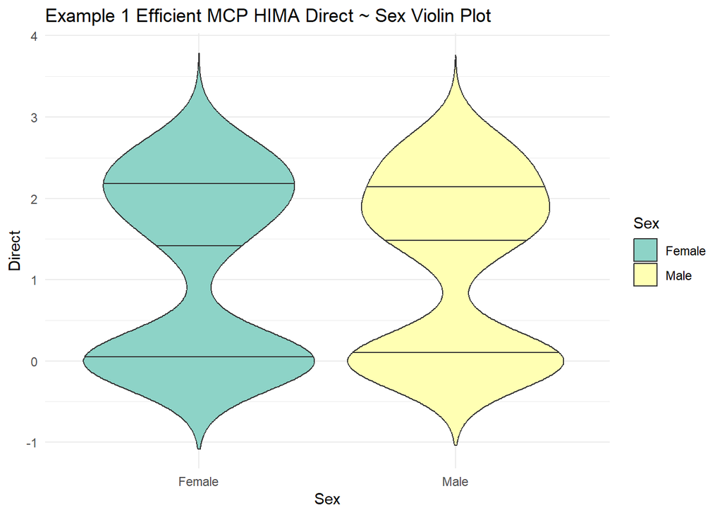

```r
E1mcpEfficient$Sex <- ifelse(E1mcpEfficient$Sex == 0, "Male", "Female")
E1mcpEfficient_sex_pl <- plot_violins(E1mcpEfficient, "Sex", "Direct", plotname = "Example 1 Efficient MCP HIMA Direct ~ Sex Violin Plot")
E1mcpEfficient_sex_pl
```

```r
boot_tests(E1mcpEfficient, "Sex", "Direct", mean)
```

```
##             2.5%    97.5%
## Male   1.0382408 1.379175
## Female 0.9918408 1.334436
```

##### Findings

The results of **MCP eHIMA** for Example 1 show:

The values for each effect are not normally distributed.

M2 has positive correlation with the direct effect. M3 has negative correlation with the direct effect.

All effects have a positive correlation with the outcome.

The direct effect and M2 have positive correlation with age.

The residuals cannot be attributed to the input data as a limiting factor.

#### Conclusion

The findings from each HIMA Method used on Example 1 in the HIMA documentation are the same. Despite having different algorithms for identifying mediators, they were all able to identify the three true mediators, and have the same **beta** values to a minimum of 6 significant digits.

## Example 2 Data Overview

### Dimensions of the Data

```r
dim(Example2$PhenoData)
```

```
## [1] 300   4
```

```r
dim(Example2$Mediator)
```

```
## [1] 300 300
```

### Data Overview

Numerical Features

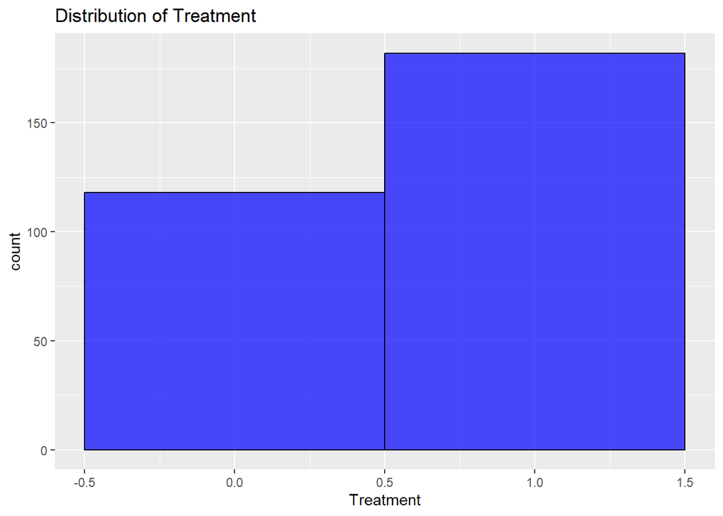

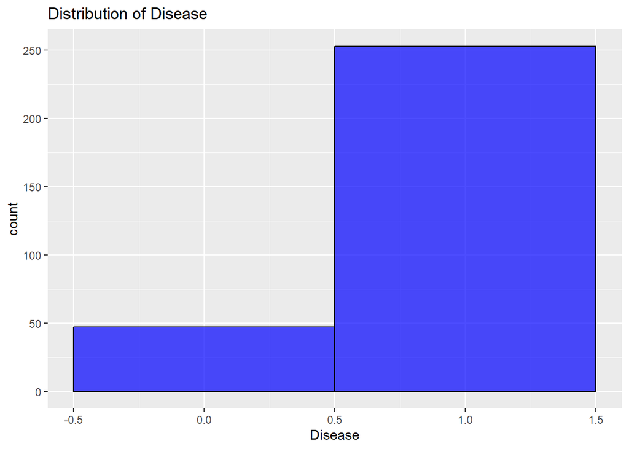

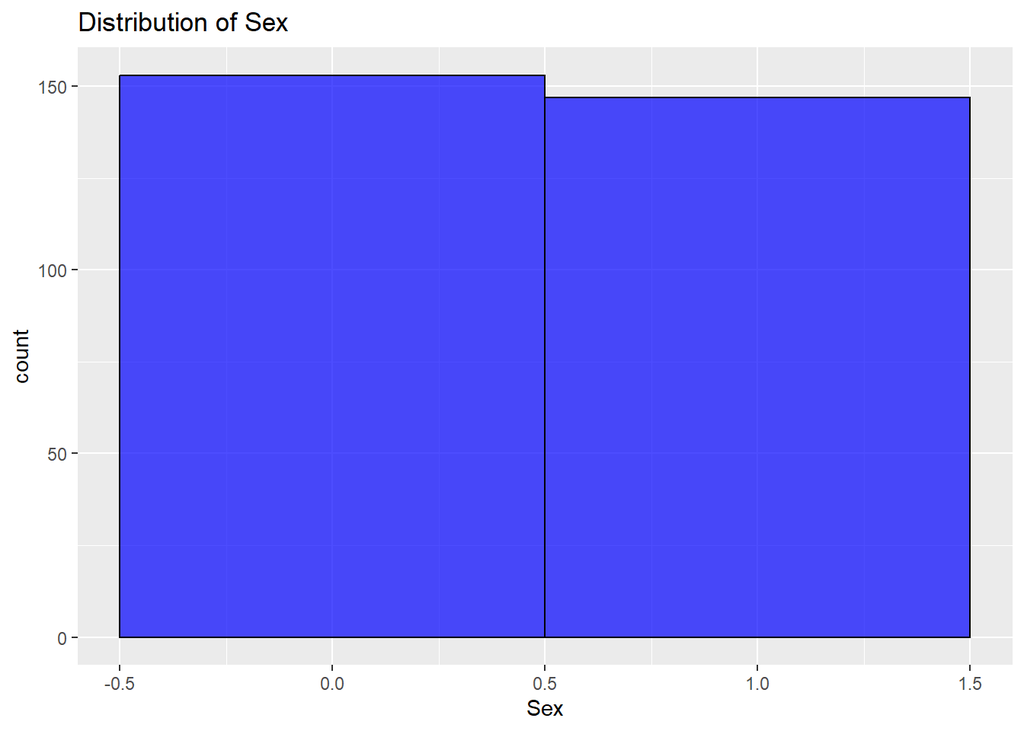

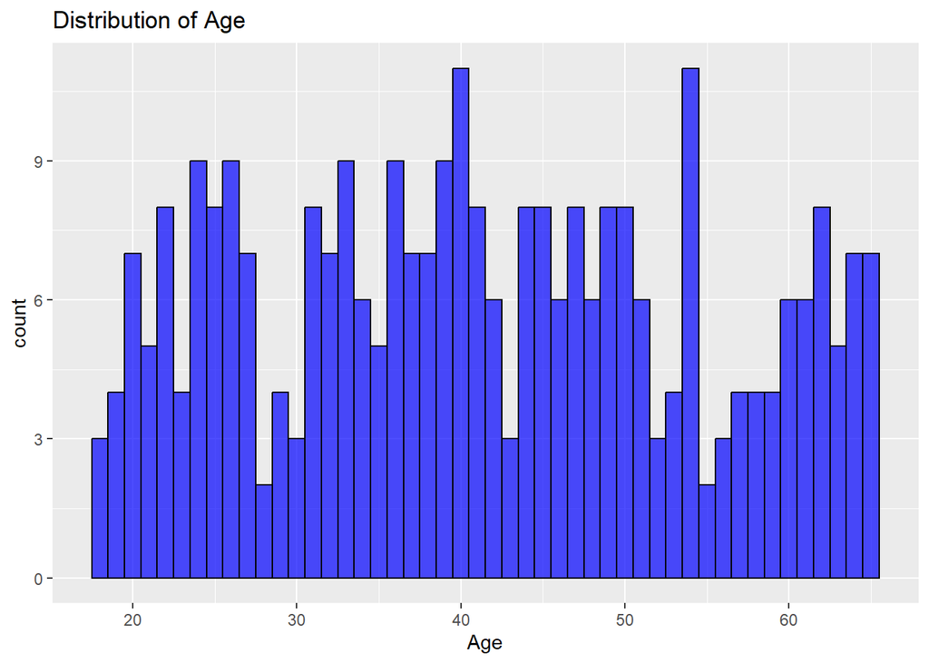

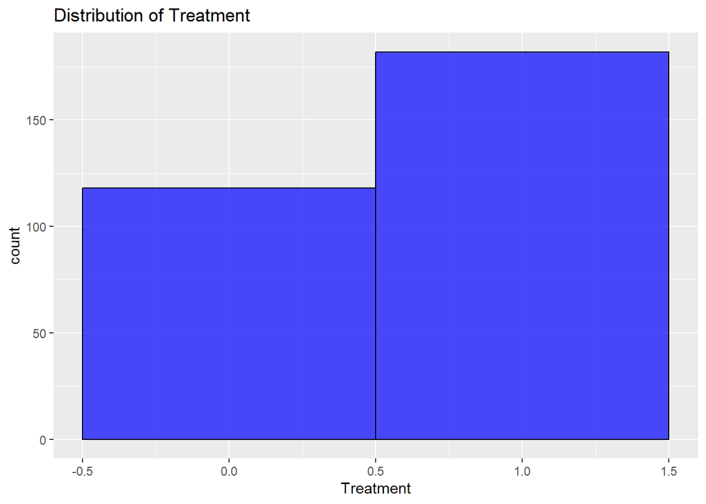

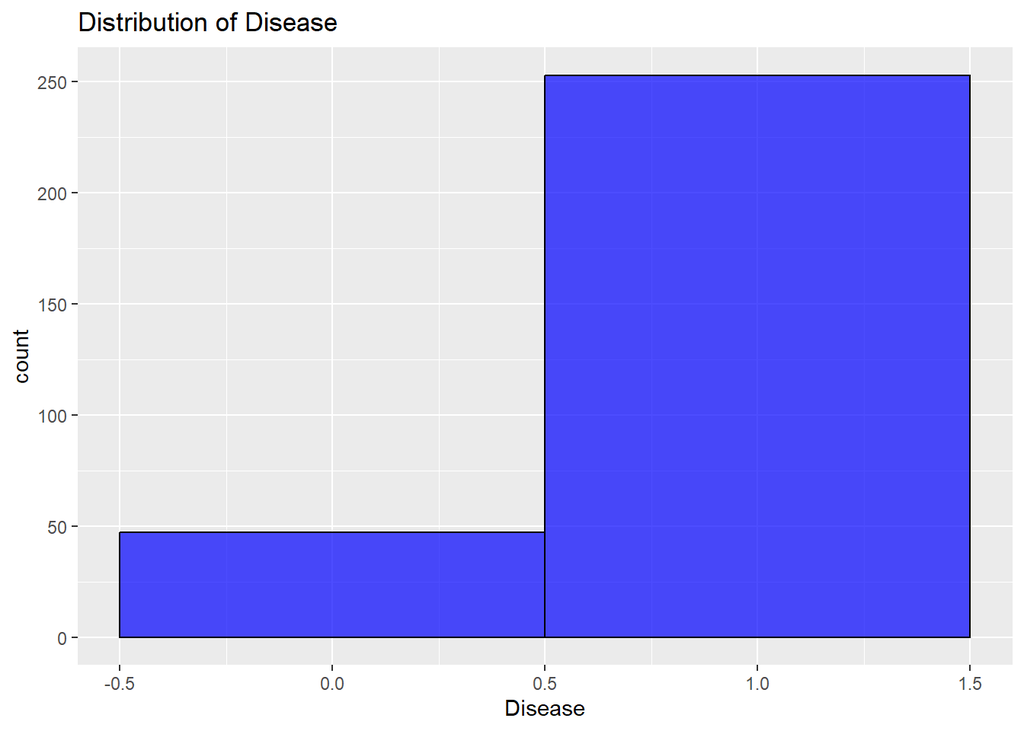

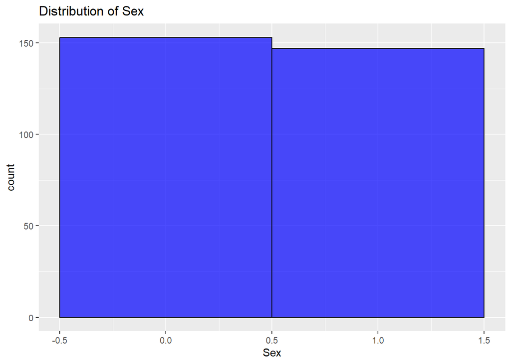

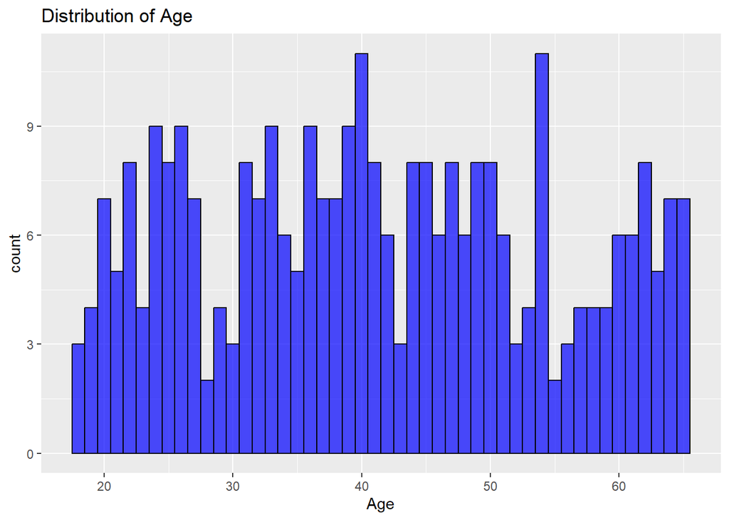

```r
# Histograms for numerical features
num_vars <- sapply(Example2$PhenoData, is.numeric)
data_numeric <- Example2$PhenoData[, num_vars]
lapply(names(data_numeric), function(var) {
  print(ggplot(Example2$PhenoData, aes_string(x = var)) +
        geom_histogram(binwidth = 1, fill = "blue", color = "black", alpha = 0.7) +
        labs(title = paste("Distribution of", var)))
})
```

```r
summary(Example2$PhenoData)
```

```
##    Treatment         Disease            Sex            Age
##  Min.   :0.0000   Min.   :0.0000   Min.   :0.00   Min.   :18.00
##  1st Qu.:0.0000   1st Qu.:1.0000   1st Qu.:0.00   1st Qu.:31.00
##  Median :1.0000   Median :1.0000   Median :0.00   Median :40.00
##  Mean   :0.6067   Mean   :0.8433   Mean   :0.49   Mean   :41.22
##  3rd Qu.:1.0000   3rd Qu.:1.0000   3rd Qu.:1.00   3rd Qu.:51.00
##  Max.   :1.0000   Max.   :1.0000   Max.   :1.00   Max.   :65.00
```

**Treatment**: A binary feature that indicates the presence of the treatment for a test subject. **1** indicates the presence of the treatment. **0** indicates the absence of the treatment.

**Disease**: A binary feature that indicates the testing result for the presence of a disease. **1** indicates a positive test result. **0** indicates a negative test result.

**Sex**: A binary feature that indicates the biological sex of the subject. **1** indicates females, and **0** indicates males.

**Age**: A continuous numerical features that represents the age of the subject in years.

Categorical Features

```r
# Bar plots for categorical features
cat_vars <- sapply(Example2$PhenoData, is.factor)
data_categorical <- Example2$PhenoData[, cat_vars, drop = FALSE]
lapply(names(data_categorical), function(var) {
  print(ggplot(Example2$PhenoData, aes_string(x = var)) +
        geom_bar(fill = "blue", color = "black", alpha = 0.7) +
        labs(title = paste("Frequency of", var)))
})
```

```
## list()
```

### Example 2 Prediction Model

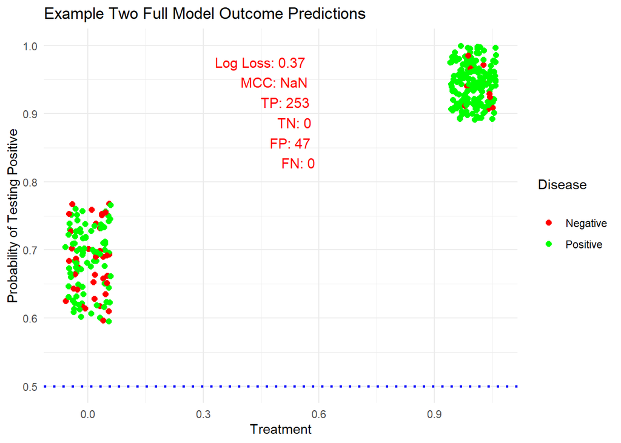

```r
Example2fullmodel <- glm(Disease ~ Treatment + Age + Sex, data = Example2$PhenoData, family = "binomial")
E2pred <- predict(Example2fullmodel, type = "response")
E2predoutcome <- ifelse(E2pred >= 0.5, 1, 0)
E2logloss <- -mean(himaDat$Example2$PhenoData$Disease * log(E2pred) + (1 - himaDat$Example2$PhenoData$Disease) * log(1 - E2pred))
E2cm <- table(E2predoutcome, himaDat$Example2$PhenoData$Disease)
if (nrow(E2cm) == 1) {
  E2cm <- rbind(E2cm, c(0,0))
  rownames(E2cm)[2] <- 1-as.numeric(rownames(E2cm)[1])
}
E2mcc <- ((E2cm["1","1"]
          * E2cm["0","0"]
          - E2cm["0","1"]
          * E2cm["1","0"])
          / sqrt((E2cm["1","1"]
                  + E2cm["1","0"])
                 * (E2cm["1","1"]
                    + E2cm["0","1"])
                 * (E2cm["0","0"]
                    + E2cm["1","0"])
                 * (E2cm["0","0"]
                    + E2cm["0","1"])))
Example2modelpl <- ggplot(data.frame(himaDat$Example2$PhenoData, Response = predict(Example2fullmodel, type = "response")),
                              aes(x = Treatment,
                                  y = Response)) +
  geom_point(position = position_jitter(width=0.06, height = 0.045),aes(color = factor(Disease)), size = 2) + # Use 'factor' to treat 'value' as categorical
  geom_hline(yintercept=0.5, linetype='dotted', linewidth = 1, col = "blue") +
  labs(title = "Example Two Full Model Outcome Predictions", x = "Treatment", y = "Probability of Testing Positive", color = "Disease\n") +
  scale_color_manual(labels = c("Negative","Positive"),values = c("0" = "red", "1" = "green")) + # Manually set colors  # Points colored by actual value
  theme_minimal() +
  annotate("text", x = 0.6, y = 1, label = paste("Log Loss:", round(E2logloss, 2), "\nMCC:", round(E2mcc, 2), "\nTP:", E2cm["1","1"],"\nTN:", E2cm["0","0"], "\nFP:", E2cm["1","0"], "\nFN:", E2cm["0","1"]),
           hjust = 1.1, vjust = 1.1, size = 4, color = "red")
Example2modelpl
```

The model needs refinement through the consideration of mediators.

### Mediation Analysis with classicHIMA

#### Mediator Identification

```r
hima.logistic.fit <- classicHIMA(
  X = himaDat$Example2$PhenoData$Treatment,
  Y = himaDat$Example2$PhenoData$Disease,
  M = himaDat$Example2$Mediator,
  COV.XM = himaDat$Example2$PhenoData[, c("Sex", "Age")],
  Y.type = "binary",
  scale = FALSE, # Disabled only for simulation data
  verbose = TRUE
)
```

```
## Running logistic HIMA with MCP penalty...
```

```
## Step 1: Sure Independent Screening ...     (3:04:17 PM)
```

```
##     Screening M using the association between X (independent variable) and M (dependent variable):     Adjusting for covariate(s): Sex, Age
##     Running Sure Independent Screening (M ~ X + COV.XM, family: gaussian) with single core...   (3:04:17 PM)
##     Top 27 mediators are selected: M2, M3, M1, M93, M120, M217, M87, M296, M74, M104, M266, M141, M165, M226, M191, M20, M180, M150, M11, M56, M147, M45, M136, M71, M12, M40, M37
## Step 2: Penalized estimate (MCP) ...     (3:04:18 PM)
##     Adjusting for covariate(s): Sex, Age
##     Tuning parameter lambda selected: 0.0278116253089298
##     Non-zero MCP beta estimate(s) of mediator(s) found: M1,M2,M3,M266
##     Using alpha estimated in Step 1 ...   (3:04:18 PM)
## Step 3: Joint significance test ...     (3:04:18 PM)
## Done!     (3:04:18 PM)
```

```r
hima.logistic.fit
```

```
##    Index  alpha_hat   beta_hat       IDE     rimp         pmax
## M1    M1  0.6096868  1.0393063 0.6336514 31.10626 1.478678e-03
## M2    M2  0.9677835  1.0148114 0.9821177 48.21264 9.257657e-08
## M3    M3 -0.6657028 -0.4412061 0.2937121 14.41847 7.601026e-04
```

```r
summary(Example2$Mediator[,hima.logistic.fit[,"Index"]])
```

```
##        M1                M2                M3
##  Min.   :-3.3039   Min.   :-3.1423   Min.   :-4.4413
##  1st Qu.:-0.1965   1st Qu.:-0.0914   1st Qu.:-1.2927
##  Median : 0.9708   Median : 0.9824   Median :-0.1783
##  Mean   : 0.8834   Mean   : 0.8541   Mean   :-0.2224
##  3rd Qu.: 1.9642   3rd Qu.: 1.9565   3rd Qu.: 0.6971
##  Max.   : 5.0112   Max.   : 6.6554   Max.   : 4.4498
```

M1, M2, and M3 have been identified as the top three most significant mediator variables. (p < 0.05)

**alpha_hat** represents the effect the treatment has on the mediators.

**beta_hat** represents the effect the mediators have towards the outcome.

**IDE** stands for “Indirect Effect”, and is the result of **alpha_hat*beta_hat**.

```r
E2classic <- estimatedEffects(fit = hima.logistic.fit,
                              type = "binary",
                              dat = himaDat$Example2,
                              X = himaDat$Example2$PhenoData$Treatment,
                              Y = himaDat$Example2$PhenoData$Disease,
                              Cov = himaDat$Example2$PhenoData[, c("Sex", "Age")])


E2classicmodelpl <- plot_mediator_adjustments(type = "binary",
              actual = himaDat$Example2$PhenoData$Disease,
              estimations = E2classic,
              mediator_indices = hima.logistic.fit[,"Index"],
              plotname = "Example Two Classic HIMA Outcome Predictions",
              labels = c("Disease", "Negative", "Positive"))
```

```
##            actual
## predoutcome   0   1
##           0  34  22
##           1  13 231
##         mcc
## 1 0.5937218
```

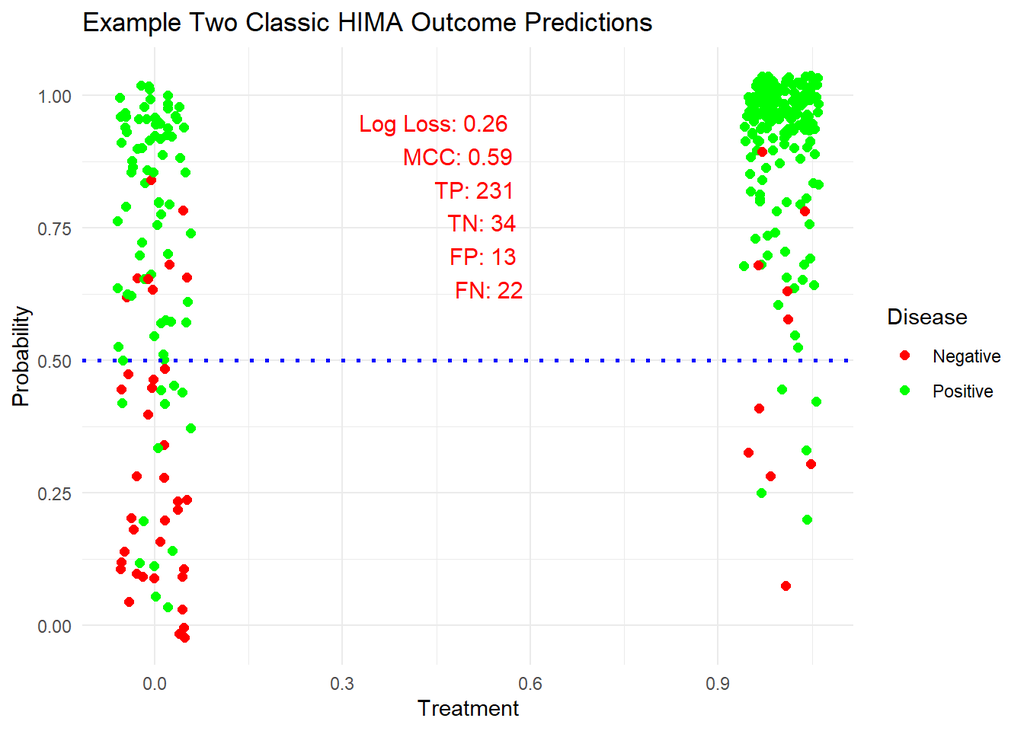

```r
E2classicmodelpl
```

The consideration of mediators allows the relationship between Treatment and Outcome to be much more accurately described.

The contribution towards the outcome by each mediator is calculated as **M * beta_hat.**

The contribution towards the outcome by the Direct Effect is calculated as the **E(Y | X, Cov) - IDE**.

The mediator adjusted prediction is **E(Y | X, M, Cov) = 𝛽*M + E(Y | X, Cov) - IDE**.

#### Effect Analysis

##### Test for Normality

*H<sub>0</sub>* : The values for every type of measured effect are drawn from the normal distribution.

*H<sub>1</sub>* : The values for every type of measured effect are drawn from outside the normal distribution.

```r
E2classic_control_ks_results <- kstests(dat = E2classic[E2classic$Treatment == 0,], exclude = c("Treatment","Sex","Other", "DominantEffect", "Direct"))
```

```
## [1] "Disease"      "Age"          "M1"           "M2"           "M3"
## [6] "totalLogOdds" "Residuals"    "Adjusted"
```

```r
print(data.frame(E2classic_control_ks_results))
```

```
##              D_Statistic       P_Value
## Disease        0.5277854  5.632513e-29
## Age            1.0000000 6.419959e-103
## M1             0.3033112  7.445057e-10
## M2             0.2594766  2.513832e-07
## M3             0.1468597  1.231608e-02
## totalLogOdds   0.7105682  3.559016e-52
## Residuals      0.1942909  2.704010e-04
## Adjusted       0.3176870  9.054633e-11
```

```r
E2classic_experimental_ks_results <- kstests(dat = E2classic[E2classic$Treatment != 0,], exclude = c("Treatment","Sex","Other", "DominantEffect", "Direct"))
```

```
## [1] "Disease"      "Age"          "M1"           "M2"           "M3"
## [6] "totalLogOdds" "Residuals"    "Adjusted"
```

```r
print(data.frame(E2classic_experimental_ks_results))
```

```
##              D_Statistic       P_Value
## Disease        0.7863997  3.455536e-98
## Age            1.0000000 1.651348e-158
## M1             0.3891530  2.295653e-24
## M2             0.4174129  5.723249e-28
## M3             0.1989352  1.108799e-06
## totalLogOdds   0.9959908 3.040010e-157
## Residuals      0.6174098  1.097805e-60
## Adjusted       0.7460679  2.037984e-88
```

##### Tests for Correlation

We reject *H<sub>0</sub>* (p < 0.05). In rejection of the null hypothesis, we shall test for whether there exists correlations between each mediator effect.

*H<sub>0</sub>* : There exists no correlation between a mediator effect and any other mediator effect.

*H<sub>1</sub>* : There exists a correlation between an effect and any other mediator effect.

```r
E2classic_effect_cor <- perform_cor_tests(E2classic, c(hima.logistic.fit[,"Index"]), alternative = "two.sided", method = "spearman")
E2classic_effect_cor
```

```
## $`M1 - M2`
##
##  Spearman's rank correlation rho
##
## data:  data[, x[i]] and data[, x[j]]
## S = 4383122, p-value = 0.6541
## alternative hypothesis: true rho is not equal to 0
## sample estimates:
##        rho
## 0.02596207
##
##
## $`M1 - M3`
##
##  Spearman's rank correlation rho
##
## data:  data[, x[i]] and data[, x[j]]
## S = 4808868, p-value = 0.2357
## alternative hypothesis: true rho is not equal to 0
## sample estimates:
##         rho
## -0.06864921
##
##
## $`M2 - M3`
##
##  Spearman's rank correlation rho
##
## data:  data[, x[i]] and data[, x[j]]
## S = 3959092, p-value = 0.03752
## alternative hypothesis: true rho is not equal to 0
## sample estimates:
##      rho
## 0.120192
```

We cannot reject the null hypothesis(adjusted p > 0.05). We will follow up on this by testing for the correlation between each effect for the experimental group, where the direct effect is always present.

*H<sub>0</sub>* : There exists no correlation between an effect and any other effect in the experimental group.

*H<sub>1</sub>* : There exists a correlation between an effect and any other effect in the experimental group.

```r
E2classic_effect_cor_e <- perform_cor_tests(E2classic[E2classic$Treatment != 0,], c(hima.logistic.fit[,"Index"], "Direct"), alternative = "two.sided", method = "spearman")
E2classic_effect_cor_e
```

```
## $`M1 - M2`
##
##  Spearman's rank correlation rho
##
## data:  data[, x[i]] and data[, x[j]]
## S = 923096, p-value = 0.2753
## alternative hypothesis: true rho is not equal to 0
## sample estimates:
##       rho
## 0.0812506
##
##
## $`M1 - M3`
##
##  Spearman's rank correlation rho
##
## data:  data[, x[i]] and data[, x[j]]
## S = 1074364, p-value = 0.3522
## alternative hypothesis: true rho is not equal to 0
## sample estimates:
##         rho
## -0.06930512
##
##
## $`M1 - Direct`
##
##  Spearman's rank correlation rho
##
## data:  data[, x[i]] and data[, x[j]]
## S = 914378, p-value = 0.2273
## alternative hypothesis: true rho is not equal to 0
## sample estimates:
##        rho
## 0.08992778
##
##
## $`M2 - M3`
##
##  Spearman's rank correlation rho
##
```

[output cut: 15 more lines]

```
## sample estimates:
##      rho
## 0.134059
##
##
## $`M3 - Direct`
##
##  Spearman's rank correlation rho
##
## data:  data[, x[i]] and data[, x[j]]
## S = 1074632, p-value = 0.3507
## alternative hypothesis: true rho is not equal to 0
## sample estimates:
##         rho
## -0.06957232
```

We fail to reject the null hypothesis: The correlation between each effect is not statistically significant( p > 0.05). We will conduct bootstrap sampling to find the true mean of each effect in the control group and experimental group.

```r
E2classic_control_long <- melt(E2classic[E2classic$Treatment == 0,hima.logistic.fit[,"Index"]], variable.name = "Effect", value.name = "Contribution")
head(E2classic_control_long)
```

```
##   Effect Contribution
## 1     M1    -2.473260
## 2     M1     1.740793
## 3     M1    -1.030691
## 4     M1    -2.704019
## 5     M1     3.769609
## 6     M1     1.297155
```

```r
E2_classic_control_pl <- plot_violins(E2classic_control_long, x = "Effect", y = "Contribution", "Example 2 Classic HIMA Control Group Effects")
E2classic_control_boot <- boot_tests(data = E2classic_control_long, x = "Effect", y = "Contribution", statistic = mean)
E2classic_control_boot
```

```
##           2.5%      97.5%
## M1  0.22811871 0.84855137
## M2 -0.01094393 0.57126282
## M3 -0.19939420 0.03013438
```

```r
E2classic_experimental_long <- melt(E2classic[E2classic$Treatment != 0,c(hima.logistic.fit[,"Index"], "Direct")], variable.name = "Effect", value.name = "Contribution")
head(E2classic_experimental_long)
```

```
##   Effect Contribution
## 1     M1   -0.6158709
## 2     M1    0.4031062
## 3     M1    3.5299368
## 4     M1    2.6375268
## 5     M1    0.3105114
## 6     M1    1.6990041
```

```r
E2classic_experimental_pl <- plot_violins(E2classic_experimental_long, x = "Effect", y = "Contribution", "Example 2 Classic HIMA Experimental Group Effects")
E2classic_experimental_boot <- boot_tests(data = E2classic_experimental_long, x = "Effect", y = "Contribution", statistic = mean)
E2classic_experimental_boot
```

```
##             2.5%     97.5%
## M1     0.9286322 1.3925811
## M2     1.0395972 1.4431388
## M3     0.1189787 0.3095239
## Direct 0.9208660 0.9768992
```

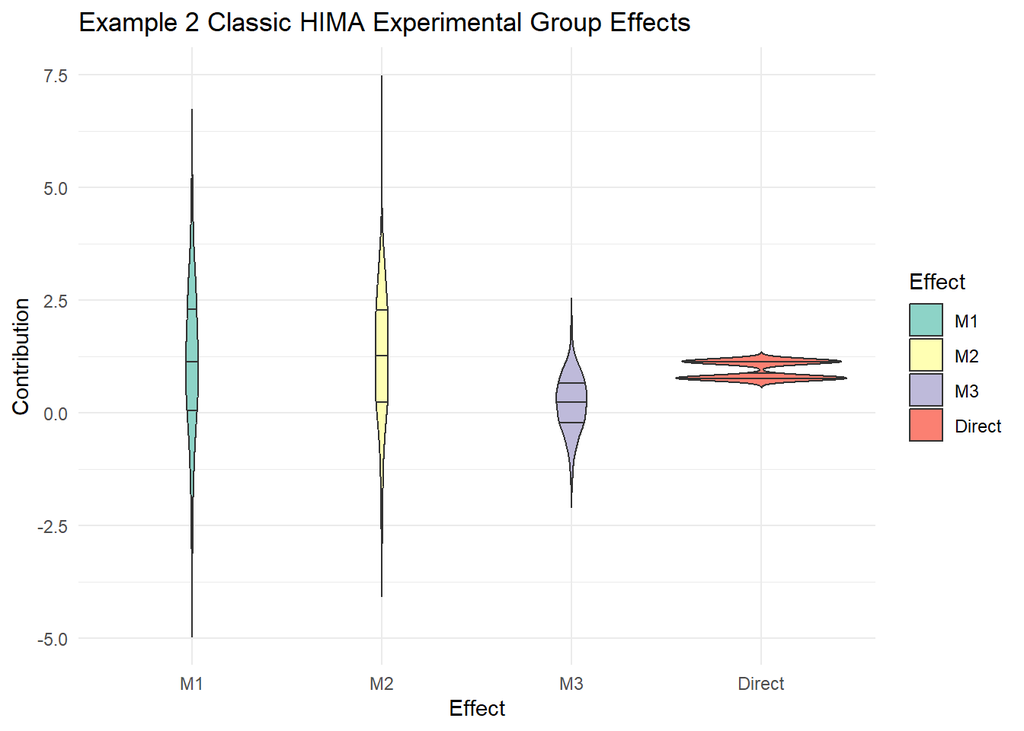

```r
E2classic_experimental_pl
```

In the experimental group, the mean contributions of each effect are much higher than they are in the control group.

We are going to test for correlations between effects and the adjusted log-odds ratio for P(1 | X, M, Cov).

*H<sub>0</sub>* : There exists no correlation between any effect and measured outcome in the experimental group.

*H<sub>1</sub>* : There exists a correlation between any effect and measured outcome in the experimental group.

```r
E2classic_effect_lor_cor <- perform_cor_tests(E2classic, x = c(hima.logistic.fit[,"Index"], "Direct"), y = "Adjusted", alternative = "two.sided", method = "spearman")
E2classic_effect_lor_cor
```

```
## $`M1 - Adjusted`
##
##  Spearman's rank correlation rho
##
## data:  data[, name] and data[, y]
## S = 1589100, p-value < 2.2e-16
## alternative hypothesis: true rho is not equal to 0
## sample estimates:
##       rho
## 0.6468627
##
##
## $`M2 - Adjusted`
##
##  Spearman's rank correlation rho
##
## data:  data[, name] and data[, y]
## S = 1516972, p-value < 2.2e-16
## alternative hypothesis: true rho is not equal to 0
## sample estimates:
##       rho
## 0.6628914
##
##
## $`M3 - Adjusted`
##
##  Spearman's rank correlation rho
##
## data:  data[, name] and data[, y]
## S = 3229260, p-value = 7.393e-07
## alternative hypothesis: true rho is not equal to 0
## sample estimates:
##       rho
## 0.2823787
##
##
## $`Direct - Adjusted`
##
##  Spearman's rank correlation rho
##
## data:  data[, name] and data[, y]
## S = 2166848, p-value < 2.2e-16
## alternative hypothesis: true rho is not equal to 0
## sample estimates:
##       rho
## 0.5184728
```

We can reject the null hypothesis(adjusted p < 0.05). For all effects, there exists positive correlation to the log-odds ratio for P(1 | X, M, Cov). We shall move on to testing for correlation between age and all effects.

*H<sub>0</sub>* : There exists no correlation between any effect and age in the experimental group.

*H<sub>1</sub>* : There exists a correlation between any effect and age in the experimental group.

```r
E2classic_effect_age_cor <- perform_cor_tests(E2classic, x = c(hima.logistic.fit[,"Index"], "Direct"), y = "Age", alternative = "two.sided", method = "spearman")
E2classic_effect_age_cor
```

```
## $`M1 - Age`
##
##  Spearman's rank correlation rho
##
## data:  data[, name] and data[, y]
## S = 4054046, p-value = 0.08665
## alternative hypothesis: true rho is not equal to 0
## sample estimates:
##        rho
## 0.09909094
##
##
## $`M2 - Age`
##
##  Spearman's rank correlation rho
##
## data:  data[, name] and data[, y]
## S = 3887503, p-value = 0.01835
## alternative hypothesis: true rho is not equal to 0
## sample estimates:
##       rho
## 0.1361008
##
##
## $`M3 - Age`
##
##  Spearman's rank correlation rho
##
## data:  data[, name] and data[, y]
## S = 4731162, p-value = 0.3752
## alternative hypothesis: true rho is not equal to 0
## sample estimates:
##         rho
## -0.05138092
##
##
## $`Direct - Age`
##
##  Spearman's rank correlation rho
##
## data:  data[, name] and data[, y]
## S = 3948223, p-value = 0.03377
## alternative hypothesis: true rho is not equal to 0
## sample estimates:
##       rho
## 0.1226073
```

We fail to reject the null hypothesis(adjusted p < 0.05). There is little statistical significance in the correlation between effects and age.